# Práctica Calificada 1 — Inferencia Multivariada (2026-II)

Pruebas Z² y T² de Hotelling, y MANOVA (DCA, DBCA y Factorial)

Flores Cueva Jose Armando

Barrientos Mauricio Fabricio Rodrigo

Carrasco Barrial Gian Piero

Puma Vilcahuaman Harly Steve

Evaristo Jacinto Gabriel Omar

Bautista Aldave Camila

18 de September de 2026

# Pregunta 1 — Inferencia respecto a un vector de medias simple (Prueba Z², Σ conocida)

**Base de datos:** `datos_barritas_energeticas.xlsx` — Composición nutricional de barras energéticas artesanales.

**Integrantes a cargo:** Flores Cueva Jose Armando, Barrientos Mauricio Fabricio Rodrigo, Carrasco Barrial Gian Piero, Puma Vilcahuaman Harly Steve, Evaristo Jacinto Gabriel Omar, Bautista Aldave Camila.

## Introducción

Las barras energéticas artesanales se comercializan con una **etiqueta nutricional declarada** por el fabricante (calorías, proteína, grasa y azúcar por cada 100 g de producto). Un control de calidad riguroso no puede evaluar cada nutriente de forma aislada, porque estos **no son independientes entre sí**: por ejemplo, un mayor contenido de grasa suele acompañarse de un mayor aporte calórico. Evaluar 4 pruebas $t$ univariadas por separado ignoraría esta estructura de correlación y, además, infla el error tipo I global (cada prueba individual arrastra su propio 5% de error, y al combinar 4 el error conjunto sube muy por encima del 5%).

Por esta razón, este trabajo aplica un enfoque **multivariado**: se contrasta si el **vector de medias poblacional** de los 4 nutrientes coincide con el vector declarado en la etiqueta, usando la prueba $Z^2$, apropiada cuando la matriz de varianzas-covarianzas $\Sigma$ del proceso de producción **se asume conocida** (por ejemplo, estimada de controles de calidad históricos, previos a esta muestra).

### Objetivos

- **Objetivo general:** determinar si el contenido nutricional promedio real de una marca de barra energética coincide con el declarado en su etiqueta.
- **Objetivos específicos:**
  1. Realizar un análisis **descriptivo** (numérico) completo de la base de datos.
  2. Realizar un análisis **gráfico** que complemente y visualice lo hallado en el análisis descriptivo.
  3. Verificar, mediante pruebas de hipótesis formales, los supuestos necesarios para aplicar $Z^2$ (normalidad univariada y multivariada, ausencia de atípicos severos).
  4. Aplicar la prueba de hipótesis $Z^2$ para el vector de medias con $\Sigma$ conocida.
  5. Interpretar y discutir los resultados en el contexto del problema.

## Marco Teórico

### Caso univariado (punto de partida)

Si $X_1,\dots,X_n$ es una muestra aleatoria de una distribución $\text{Normal}(\mu,\sigma^2)$ y $\sigma^2$ es **conocida**, el estadístico de prueba para $H_0:\mu=\mu_0$ es:

$$Z=\frac{(\bar X-\mu_0)\sqrt n}{\sigma}\sim \text{Normal}(0,1)$$

Elevando al cuadrado se obtiene una forma equivalente, que es la que se generaliza al caso multivariado:

$$Z^2 = n(\bar X-\mu_0)\,\sigma^{-2}(\bar X-\mu_0) \sim \chi^2(1)$$

### Extensión al caso multivariado

Sea $\underline{X}_i \overset{iid}{\sim} N_p(\underline\mu,\Sigma)$, con $i=1,\dots,n$, donde:

- $\underline{X}_i=(X_{i1},\dots,X_{ip})'$ es el vector $p\times 1$ de la observación $i$.
- $\underline\mu=(\mu_1,\dots,\mu_p)'$ es el vector de medias poblacionales $p\times1$.
- $\Sigma=\{\sigma_{jh}\}$ es la matriz de covarianzas $p\times p$, **asumida conocida**.

El estadístico de prueba general es:

$$Z^2 = n(\bar{\underline
X}-\underline\mu_0)'\,\Sigma^{-1}\,(\bar{\underline
X}-\underline\mu_0) \;\sim\; \chi^2(p) \quad \text{bajo } H_0$$

Es unilateral a la derecha porque $Z^2$ es una **forma cuadrática** (siempre $\geq 0$) que mide una distancia estadística entre $\bar{\underline X}$ y $\underline\mu_0$: no importa la dirección de la diferencia, solo su magnitud. Por eso solo se rechaza $H_0$ cuando $Z^2$ es “demasiado grande”.

### Supuestos requeridos para aplicar $Z^2$

1. Los datos provienen de **una sola población** normal multivariada $N_p(\underline\mu,\Sigma)$ — esto se verifica con pruebas de normalidad (univariadas y multivariada).
2. La matriz $\Sigma$ es conocida (no se estima de la muestra en estudio) — se verifica de forma complementaria con la **prueba de razón de verosimilitud para una matriz de covarianza poblacional conocida** ($H_0:\Sigma=\Sigma_0$), implementada en R mediante la función `Bcov()`.
3. Ausencia de valores atípicos severos que distorsionen el vector de medias muestral — se verifica con la distancia de Mahalanobis.

> **Hoja de ruta de este documento:** primero se presenta la base de datos, luego el **análisis descriptivo** (tablas numéricas), después el **análisis gráfico** (visualizaciones), y finalmente la sección de **pruebas de hipótesis**, donde cada supuesto y la prueba $Z^2$ se presentan como fichas independientes con su hipótesis, estadístico, regla de decisión y conclusión.

## Descripción General de la Base de Datos

| Variable | Descripción | Unidad | Tipo |
| --- | --- | --- | --- |
| `id` | Identificador de la muestra | - | Numérica |
| `calorias` | Contenido energético | kcal / 100 g | Cuantitativa continua |
| `proteina` | Contenido de proteína | g / 100 g | Cuantitativa continua |
| `grasa` | Contenido de grasa total | g / 100 g | Cuantitativa continua |
| `azucar` | Contenido de azúcares | g / 100 g | Cuantitativa continua |
| `marca` | Marca de la barra energética | - | Cualitativa (factor) |

La base contiene **150 muestras** (50 por cada una de 3 marcas: *Andina*, *Boreal* y *Cusqueña*). Dado que la prueba $Z^2$ exige que los datos provengan de **una sola población**, la sub-muestra de estudio para esta pregunta es la marca **Cusqueña** ($n=50$, $p=4$ variables). El análisis descriptivo y gráfico general (con las 3 marcas) se presenta primero para dar contexto; luego se enfoca en Cusqueña.

```r
datos <- read_excel("datos_barritas_energeticas.xlsx")
datos <- datos[, -1]                     # se descarta "id"
datos$marca <- as.factor(datos$marca)
datos <- as.data.frame(datos)            # readxl devuelve un tibble; lo pasamos a data.frame

str(datos)
```

```
## 'data.frame':    150 obs. of  5 variables:
##  $ calorias: num  500 432 453 471 494 ...
##  $ proteina: num  9.96 7.48 3.55 9.71 11.56 ...
##  $ grasa   : num  18.6 18.4 13.9 12.7 21.1 ...
##  $ azucar  : num  22.4 21.2 23.7 24.9 21 ...
##  $ marca   : Factor w/ 3 levels "Andina","Boreal",..: 3 2 1 2 3 1 2 2 1 2 ...
```

```r
datos_cus <- datos %>% filter(marca == "Cusqueña")
datos1 <- datos_cus %>% select(calorias, proteina, grasa, azucar)

dim(datos1)
```

```
## [1] 50  4
```

## Análisis Descriptivo

Esta sección presenta **únicamente estadísticos numéricos** (medias, dispersión, forma de la distribución, frecuencias). Los gráficos correspondientes se presentan en la siguiente sección, para no mezclar ambos tipos de análisis.

### Estadísticos descriptivos de la base completa (3 marcas)

```r
datos_num_general <- datos %>% select(calorias, proteina, grasa, azucar)

psych::describe(datos_num_general) %>%
  as.data.frame() %>%
  select(n, mean, sd, median, min, max, skew, kurtosis) %>%
  kable(digits = 2, caption = "Estadísticos descriptivos - Base completa (150 obs.)") %>%
  kable_styling(bootstrap_options = c("striped","hover","condensed"), full_width = TRUE)
```

Estadísticos descriptivos - Base completa (150 obs.)

|  | n | mean | sd | median | min | max | skew | kurtosis |
| --- | --- | --- | --- | --- | --- | --- | --- | --- |
| calorias | 150 | 474.58 | 35.65 | 471.20 | 397.90 | 565.40 | 0.20 | -0.64 |
| proteina | 150 | 9.18 | 2.25 | 9.20 | 3.55 | 15.49 | 0.11 | -0.17 |
| grasa | 150 | 17.40 | 3.37 | 17.52 | 7.25 | 24.93 | -0.35 | 0.04 |
| azucar | 150 | 22.15 | 3.59 | 21.99 | 14.12 | 30.46 | 0.15 | -0.59 |

**Lectura:**

- `calorias` presenta la mayor dispersión absoluta (desviación estándar más alta), esperable porque su escala numérica es mucho mayor que la de las demás variables.
- `proteina` y `grasa` muestran coeficientes de asimetría (`skew`) cercanos a cero, sugiriendo distribuciones razonablemente simétricas.
- La `kurtosis` cercana a 0 en la mayoría de variables sugiere colas similares a las de una distribución normal (ni muy “puntiagudas” ni muy “planas”).

### Frecuencia de la variable cualitativa (marca)

```r
table(datos$marca)
```

```
##
##   Andina   Boreal Cusqueña
##       50       50       50
```

```r
datos %>% freq_table(marca)
```

| marca | n | prop |
| --- | --- | --- |
| Andina | 50 | 33.3 |
| Boreal | 50 | 33.3 |
| Cusqueña | 50 | 33.3 |

**Lectura:** diseño **balanceado**, con exactamente 50 observaciones por marca — condición deseable para comparaciones futuras entre grupos.

### Matriz de correlaciones (valores numéricos)

```r
datos_num <- datos %>% select(calorias, proteina, grasa, azucar)

cor_mat(datos_num, method = "pearson") %>%
  cor_mark_significant() %>%
  kable(caption = "Matriz de correlaciones de Pearson (con significancia)") %>%
  kable_styling(bootstrap_options = c("striped","hover","condensed"))
```

Matriz de correlaciones de Pearson (con significancia)

| rowname | calorias | proteina | grasa | azucar |
| --- | --- | --- | --- | --- |
| calorias |  |  |  |  |
| proteina | 0.44**** |  |  |  |
| grasa | 0.57**** | 0.43**** |  |  |
| azucar | 0.37**** | 0.22** | 0.43**** |  |

**Lectura:** existe una correlación **positiva y notoria entre calorías y grasa**, coherente con el hecho nutricional de que la grasa aporta más energía por gramo que otros macronutrientes. Esta correlación es la razón estadística de fondo por la que **no se deben analizar las 4 variables por separado** con 4 pruebas $t$ univariadas: se perdería la información de cómo covarían, y por eso se necesita el enfoque **multivariado** ($Z^2$).

### Estadísticos descriptivos de la sub-muestra: Marca “Cusqueña”

```r
head(datos1, 10) %>%
  kable(digits = 2, caption = "Primeras 10 observaciones - Marca Cusqueña")
```

Primeras 10 observaciones - Marca Cusqueña

| calorias | proteina | grasa | azucar |
| --- | --- | --- | --- |
| 500.4 | 9.96 | 18.58 | 22.45 |
| 494.3 | 11.56 | 21.06 | 21.01 |
| 530.5 | 9.98 | 17.54 | 22.98 |
| 501.1 | 10.85 | 21.49 | 23.27 |
| 496.8 | 7.81 | 15.31 | 25.49 |
| 489.8 | 6.45 | 16.91 | 26.78 |
| 471.1 | 8.98 | 19.57 | 20.21 |
| 524.9 | 10.14 | 17.78 | 21.84 |
| 514.2 | 15.49 | 20.87 | 18.95 |
| 545.7 | 9.45 | 21.07 | 24.80 |

```r
psych::describe(datos1) %>%
  as.data.frame() %>%
  select(n, mean, sd, median, min, max, skew, kurtosis) %>%
  kable(digits = 2, caption = "Estadísticos descriptivos - Marca Cusqueña (n = 50)") %>%
  kable_styling(bootstrap_options = c("striped","hover","condensed"))
```

Estadísticos descriptivos - Marca Cusqueña (n = 50)

|  | n | mean | sd | median | min | max | skew | kurtosis |
| --- | --- | --- | --- | --- | --- | --- | --- | --- |
| calorias | 50 | 502.61 | 28.30 | 501.90 | 436.60 | 565.40 | 0.00 | -0.34 |
| proteina | 50 | 10.00 | 2.14 | 10.00 | 5.64 | 15.49 | 0.11 | -0.25 |
| grasa | 50 | 19.80 | 2.52 | 20.03 | 12.96 | 24.93 | -0.31 | -0.24 |
| azucar | 50 | 22.55 | 3.51 | 22.58 | 14.12 | 28.96 | -0.19 | -0.31 |

**Lectura:** esta es la tabla de referencia para toda la sección de pruebas de hipótesis: aquí están los valores de $\bar{\underline X}$ (columna `mean`) que se compararán contra el vector hipotético $\underline\mu_0$ declarado en la etiqueta.

## Análisis Gráfico

Esta sección presenta las **visualizaciones** correspondientes a los datos descritos numéricamente arriba. El orden sigue la misma lógica: primero gráficos generales (3 marcas), luego gráficos específicos de la sub-muestra Cusqueña.

### Distribución de cada variable (histogramas)

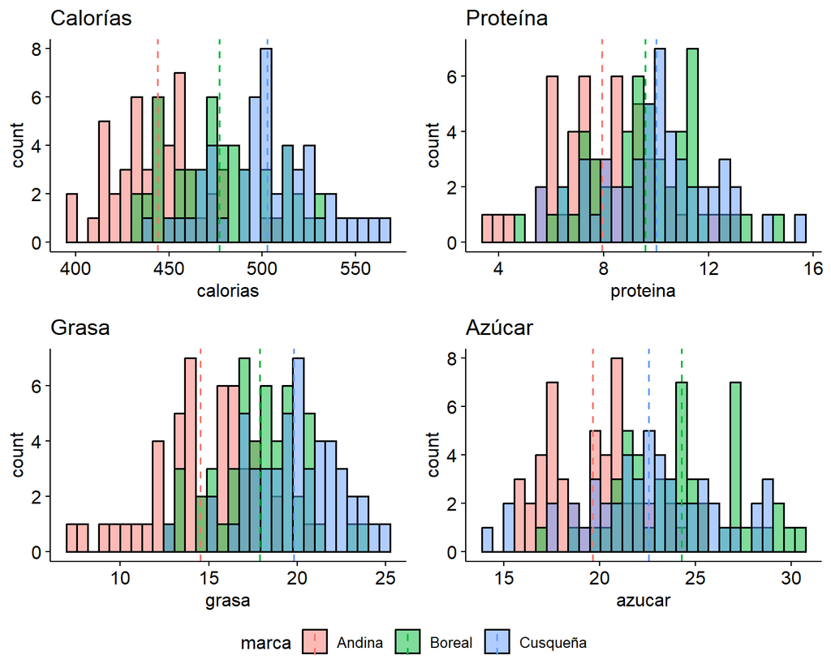

```r
h1 <- gghistogram(datos, x = "calorias", add = "mean", fill = "marca", alpha = 0.5,
                   title = "Calorías")
h2 <- gghistogram(datos, x = "proteina", add = "mean", fill = "marca", alpha = 0.5,
                   title = "Proteína")
h3 <- gghistogram(datos, x = "grasa", add = "mean", fill = "marca", alpha = 0.5,
                   title = "Grasa")
h4 <- gghistogram(datos, x = "azucar", add = "mean", fill = "marca", alpha = 0.5,
                   title = "Azúcar")

ggarrange(h1, h2, h3, h4, ncol = 2, nrow = 2, common.legend = TRUE, legend = "bottom")
```

**Lectura:** se observan visualmente las diferencias entre marcas (cada color ocupa una zona distinta del eje x), y en general las formas se aproximan a una campana, sin asimetrías extremas — esto es la **contraparte visual** de los coeficientes de asimetría/curtosis vistos en la tabla descriptiva.

### Comparación entre marcas (boxplots)

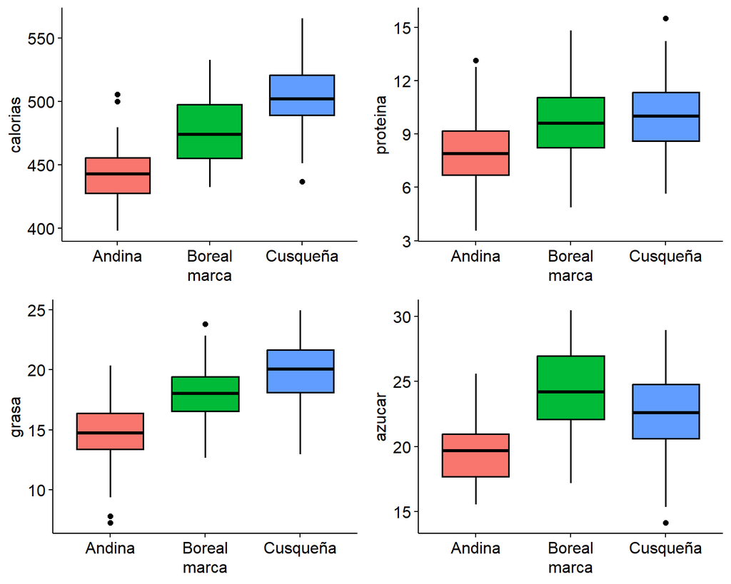

```r
b1 <- ggboxplot(datos, x = "marca", y = "calorias", fill = "marca", legend = "none")
b2 <- ggboxplot(datos, x = "marca", y = "proteina", fill = "marca", legend = "none")
b3 <- ggboxplot(datos, x = "marca", y = "grasa", fill = "marca", legend = "none")
b4 <- ggboxplot(datos, x = "marca", y = "azucar", fill = "marca", legend = "none")

ggarrange(b1, b2, b3, b4, ncol = 2, nrow = 2)
```

**Lectura:** los boxplots permiten ver simultáneamente la mediana, la dispersión (rango intercuartílico) y posibles atípicos (puntos aislados) de cada nutriente por marca. Cusqueña tiende a mostrar valores centrales más altos en calorías y proteína frente a las otras dos marcas.

### Mapa de calor de correlaciones (versión gráfica de la tabla anterior)

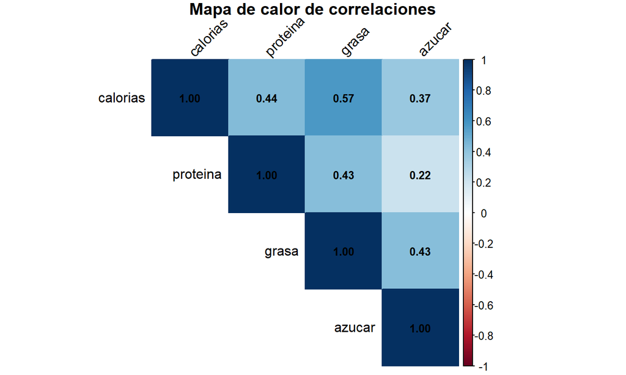

```r
M <- cor(datos_num)
corrplot(M, method = "color", type = "upper", addCoef.col = "black",
         tl.col = "black", tl.srt = 45, number.cex = 0.8,
         title = "Mapa de calor de correlaciones", mar = c(0,0,1,0))
```

### Matriz de dispersión multivariada (relación entre pares de variables)

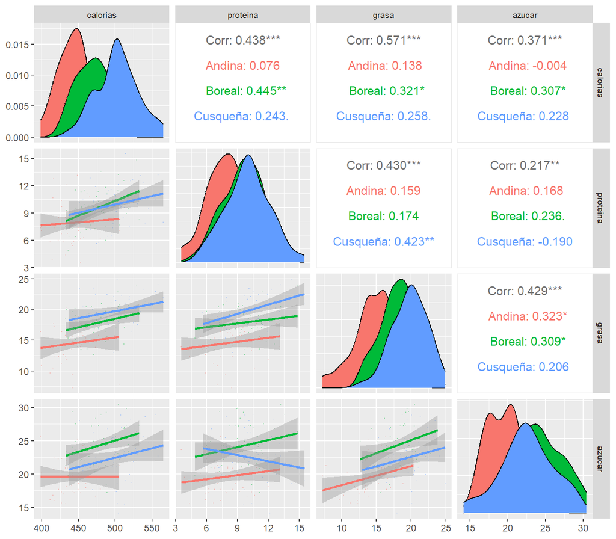

```r
datos %>% ggpairs(
  mapping = aes(colour = marca),
  columns = 1:4,
  lower = list(continuous = wrap("smooth", alpha = 0.3, size = 0.1)),
  upper = list(continuous = wrap("cor", size = 4))
) +
  theme(strip.text = element_text(size = 8))
```

**Lectura:** en la diagonal se observa la distribución de cada variable segmentada por marca; en la parte inferior, la nube de puntos y una línea de tendencia por par de variables; en la parte superior, el coeficiente de correlación. Esta es la vista más completa del comportamiento conjunto de los datos, y resume en un solo gráfico todo lo discutido en el análisis descriptivo.

### Gráficos específicos de la sub-muestra “Cusqueña”: Q-Q plots

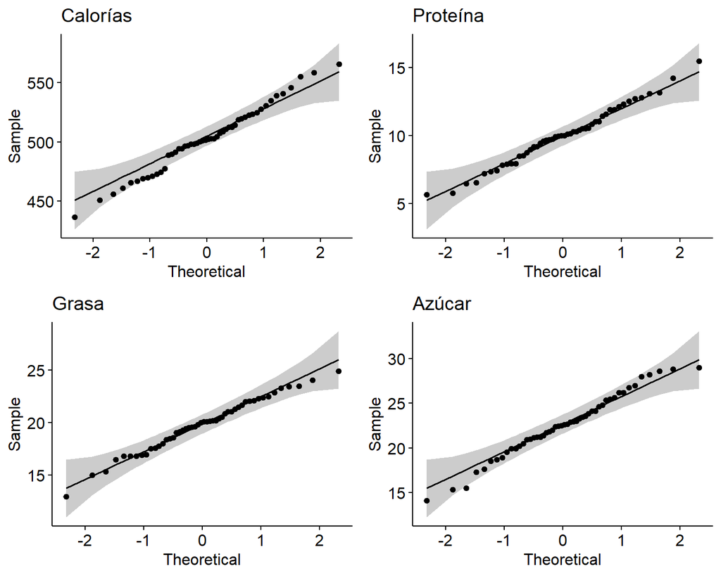

```r
q1 <- ggqqplot(datos1$calorias, title = "Calorías")
q2 <- ggqqplot(datos1$proteina, title = "Proteína")
q3 <- ggqqplot(datos1$grasa, title = "Grasa")
q4 <- ggqqplot(datos1$azucar, title = "Azúcar")

ggarrange(q1, q2, q3, q4, ncol = 2, nrow = 2)
```

**Lectura:** en un Q-Q plot, si los puntos siguen aproximadamente la línea diagonal, la variable es compatible con una distribución normal. Desviaciones marcadas en las colas indicarían posibles atípicos o asimetría. Estos gráficos son el **respaldo visual** de las pruebas formales de normalidad que se presentan a continuación.

## Pruebas de Hipótesis

En esta sección se presenta **cada prueba de hipótesis como una ficha independiente**, con la misma estructura: contexto, hipótesis, estadístico, regla de decisión, código, resultado e interpretación. El orden sigue la lógica lógica del análisis: primero se verifican los **supuestos** (normalidad, atípicos), y al final se aplica la **prueba principal** ($Z^2$).

### Prueba 1 — Normalidad univariada de “calorias” (supuesto previo)

**Contexto:** antes de aplicar cualquier prueba (univariada o multivariada), conviene verificar si cada variable, vista de forma individual, es compatible con una distribución normal.

**Hipótesis:**
$$H_0:
\text{calorias se distribuye Normal} \qquad \text{vs.} \qquad H_1:
\text{calorias no se distribuye Normal}$$

**Pruebas usadas:** Shapiro-Wilk y Lilliefors (Kolmogorov-Smirnov corregido).

**Regla de decisión:** se rechaza $H_0$ si el p-valor $< 0.05$.

```r
shapiro.test(datos1$calorias)
```

```
##
##  Shapiro-Wilk normality test
##
## data:  datos1$calorias
## W = 0.98819, p-value = 0.8951
```

```r
lillie.test(datos1$calorias)
```

```
##
##  Lilliefors (Kolmogorov-Smirnov) normality test
##
## data:  datos1$calorias
## D = 0.08453, p-value = 0.498
```

**Interpretación:** si ambos p-valores son mayores a 0.05, no se rechaza $H_0$: es razonable asumir que `calorias` sigue una distribución normal. Este resultado es el primer respaldo (parcial) del supuesto de normalidad multivariada que se necesita para $Z^2$.

### Prueba 2 — Z univariada para “calorias” con $\sigma$ conocida (puente pedagógico)

**Contexto:** replicamos, en una sola variable, exactamente la misma lógica que usaremos después en 4 dimensiones. Sirve como puente para entender la prueba multivariada.

**Hipótesis:**
$$H_0:\mu=490
\qquad \text{vs.} \qquad H_1:\mu\neq 490$$

**Estadístico:** $Z=\dfrac{(\bar X-\mu_0)\sqrt n}{\sigma} \sim N(0,1)$, con $\sigma=25$ asumida conocida.

**Regla de decisión:** se rechaza $H_0$ si $|Z| > Z_{\alpha/2}=1.96$ (equivalente a p-valor $<0.05$).

```r
BSDA::z.test(datos1$calorias, alternative = "two.sided", mu = 490,
             sigma.x = 25, conf.level = 0.95)
```

```
##
##  One-sample z-Test
##
## data:  datos1$calorias
## z = 3.5666, p-value = 0.0003616
## alternative hypothesis: true mean is not equal to 490
## 95 percent confidence interval:
##  495.6805 509.5395
## sample estimates:
## mean of x
##    502.61
```

**Interpretación:** este resultado anticipa, para una sola variable, lo que veremos de forma conjunta en la Prueba 5 ($Z^2$): si aquí ya se rechaza $H_0$, es una señal de que el vector completo probablemente también se alejará de $\underline\mu_0$.

### Prueba 3 — Normalidad multivariada (supuesto clave para $Z^2$)

**Contexto:** $Z^2$ exige que las 4 variables, tomadas **conjuntamente**, sean compatibles con una distribución normal multivariada $N_4(\underline\mu,\Sigma)$ — no basta con que cada una sea normal por separado.

**Hipótesis:**
$$H_0:
\text{la muestra proviene de una } N_4(\underline\mu,\Sigma) \qquad
\text{vs.} \qquad H_1: \text{no proviene de }
N_4(\underline\mu,\Sigma)$$

**Prueba usada:** Shapiro-Wilk multivariado (`mshapiro.test`).

**Regla de decisión:** se rechaza $H_0$ si el p-valor $< 0.05$.

```r
mshapiro.test(t(datos1))
```

```
##
##  Shapiro-Wilk normality test
##
## data:  Z
## W = 0.96705, p-value = 0.1751
```

**Interpretación:** si el p-valor es **mayor** a 0.05, no se rechaza $H_0$: es razonable asumir normalidad multivariada y, por lo tanto, es **válido** aplicar $Z^2$. Si el p-valor fuera menor a 0.05, se debería advertir en la exposición que el supuesto no se cumple estrictamente (aunque con $n=50$ —muestra moderada— $Z^2$ suele ser razonablemente robusta ante desviaciones leves, por el Teorema Central del Límite aplicado al vector de medias).

### Prueba 4 — Detección de valores atípicos multivariados

**Contexto:** un solo dato extremo puede distorsionar fuertemente el vector de medias muestral $\bar{\underline X}$ y, con ello, el resultado de $Z^2$. Por eso se revisa antes de aplicar la prueba principal.

**Criterio:** distancia de Mahalanobis de cada observación respecto al centro de los datos; se considera atípica si excede el percentil 97.5 de una $\chi^2(p)$.

```r
# NOTA TECNICA: el paquete MVN cambio la sintaxis de sus argumentos a
# partir de la version 6.x (de camelCase a snake_case, ej. "mvnTest" ->
# "mvn_test", "multivariateOutlierMethod" -> "multivariate_outlier_method"),
# y los resultados ahora se consultan con summary()/plot() en vez de
# imprimir o graficar el objeto directamente.
outliers_cus <- mvn(data = datos1, multivariate_outlier_method = "quan")
summary(outliers_cus, select = "outliers")
```

```
##   Observation Mahalanobis.Distance
## 1          49               14.715
## 2          12               13.468
## 3          39               12.683
## 4          20               11.874
## 5          13               11.758
## 6          18               11.547
```

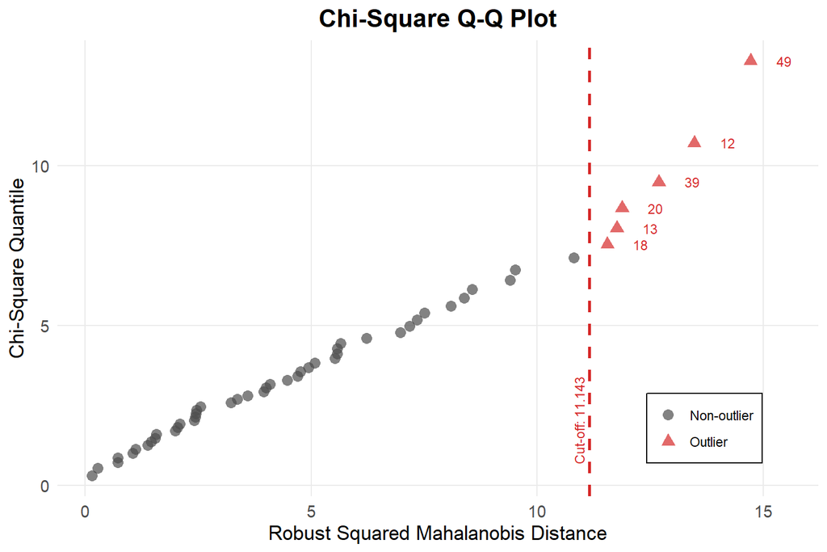

```r
plot(outliers_cus, diagnostic = "outlier")
```

**Interpretación:** las observaciones marcadas (si las hubiera) superan el umbral esperado de distancia de Mahalanobis bajo normalidad multivariada. Pocos puntos marcados significa que no hay evidencia fuerte de contaminación en los datos, y que el vector de medias muestral es una estimación confiable del centro de la distribución.

### Prueba 5 — $Z^2$: Prueba principal para el vector de medias (Sigma conocida)

Esta es **la prueba central** de esta pregunta. Todas las pruebas anteriores (1 a 4) fueron verificaciones de supuestos necesarios para que esta prueba sea válida.

**Contexto del problema:** se desea verificar si el contenido nutricional promedio real de la marca Cusqueña coincide con lo declarado en su etiqueta.

**Parámetros y datos:**

```r
n <- nrow(datos1)   # tamaño de muestra
p <- ncol(datos1)   # numero de variables

# Vector de medias hipotetico: valores declarados en la etiqueta nutricional
mu0 <- c(490, 9.5, 18, 21)

# Matriz de varianza-covarianza CONOCIDA (control de calidad historico)
sigma <- matrix(c(
  625, 10,  8,   5,
   10,  4,  1,   0.5,
    8,  1,  6,   1,
    5,  0.5,1,   9
), nrow = p, byrow = TRUE)
rownames(sigma) <- colnames(sigma) <- names(datos1)

sigma %>% kable(digits = 2, caption = "Matriz $\\Sigma$ asumida conocida (calorías, proteína, grasa, azúcar)")
```

Matriz $\Sigma$ asumida conocida (calorías, proteína, grasa, azúcar)

|  | calorias | proteina | grasa | azucar |
| --- | --- | --- | --- | --- |
| calorias | 625 | 10.0 | 8 | 5.0 |
| proteina | 10 | 4.0 | 1 | 0.5 |
| grasa | 8 | 1.0 | 6 | 1.0 |
| azucar | 5 | 0.5 | 1 | 9.0 |

**Hipótesis formal:**

$$H_0:\underline\mu=\underline\mu_0=(490,\;9.5,\;18,\;21)' \qquad
\text{vs.} \qquad H_1:\underline\mu\neq\underline\mu_0$$

En palabras: “el vector de medias nutricional real coincide con el declarado en la etiqueta” vs. “difiere de lo declarado”.

**Estadístico de prueba:**

$$Z^2 = n(\bar{\underline
X}-\underline\mu_0)'\,\Sigma^{-1}\,(\bar{\underline
X}-\underline\mu_0) \;\sim\; \chi^2(p)$$

**Regla de decisión (unilateral a la derecha):** se rechaza $H_0$ si $Z^2 > \chi^2_{p,\,0.95}$.

```r
media_muestral <- colMeans(datos1)
media_muestral
```

```
## calorias proteina    grasa   azucar
## 502.6100   9.9994  19.8046  22.5480
```

```r
diff_vec <- media_muestral - mu0
Z2 <- as.numeric(t(diff_vec) %*% solve(sigma / n) %*% diff_vec)

valor_critico <- qchisq(0.95, df = p)
p_valor <- 1 - pchisq(Z2, df = p)

data.frame(
  Estadistico = c("Z^2 calculado", "Valor critico Chi2(4, 0.95)", "p-valor"),
  Valor = c(round(Z2,4), round(valor_critico,4), format.pval(p_valor, digits = 4))
) %>% kable(caption = "Resultados de la prueba Z^2")
```

Resultados de la prueba Z^2

| Estadistico | Valor |
| --- | --- |
| Z^2 calculado | 43.6022 |
| Valor critico Chi2(4, 0.95) | 9.4877 |
| p-valor | 7.76e-09 |

**Decisión:**

```r
if (Z2 > valor_critico) {
  cat("Se RECHAZA H0 (Z^2 =", round(Z2,3), "> valor critico =", round(valor_critico,3), ")\n")
  cat("El vector de medias real difiere significativamente del declarado en la etiqueta.\n")
} else {
  cat("No se rechaza H0.\n")
}
```

```
## Se RECHAZA H0 (Z^2 = 43.602 > valor critico = 9.488 )
## El vector de medias real difiere significativamente del declarado en la etiqueta.
```

**Interpretación:** dado que $Z^2$ (≈ 43.6) es muy superior al valor crítico $\chi^2_{4,0.95}\approx 9.49$, y el p-valor es prácticamente cero, existe evidencia estadística contundente, al 95% de confianza, de que el contenido nutricional real de la barra Cusqueña **difiere** de lo declarado en su etiqueta. Recordemos que $Z^2$ es una distancia (siempre positiva) entre $\bar{\underline X}$ y $\underline\mu_0$, ponderada por la incertidumbre de $\Sigma$: cuanto más grande, más lejos está la muestra del valor hipotético.

#### Análisis Post-Hoc: ¿qué nutriente(s) provocan el rechazo de $H_0$?

**¿Por qué se hace un análisis post-hoc, y por qué recién ahora (después de rechazar $H_0$)?**

La prueba $Z^2$ es una prueba **global** o **ómnibus**: contrasta simultáneamente las 4 componentes del vector de medias en una sola decisión. Rechazar $H_0$ nos dice que **en algún lugar del vector** hay una diferencia significativa respecto a $\underline\mu_0$, pero **no nos dice cuál(es) componente(s)** son responsables de esa diferencia. Para responder esa pregunta se necesita un análisis **post-hoc** (“después del hecho”), exactamente con la misma lógica que se usa en ANOVA: primero se corre la prueba $F$ global y, **solo si esta resulta significativa**, se procede a comparaciones específicas (Tukey, Bonferroni, etc.).

El orden importa por una razón estadística concreta, y no es un simple formalismo:

1. **Control del error Tipo I (procedimiento protegido):** si se comparara cada una de las $p=4$ variables por separado con su propia prueba individual al 5% de significancia **sin haber pasado primero por la prueba global**, la probabilidad de encontrar *al menos una* diferencia “significativa” por puro azar ya no sería el 5% nominal, sino:
   $$1-(1-\alpha)^p = 1-(0.95)^4 \approx 18.5\%$$
   Es decir, casi 1 de cada 5 veces se detectaría una diferencia falsa solo por hacer múltiples comparaciones sin corrección. La prueba $Z^2$ actúa como una especie de “portero” (*gatekeeper*): solo si el vector completo resulta significativo se procede a mirar el detalle, evitando así inflar el error de tipo I con comparaciones exploratorias no planificadas.
2. **Mejora en la precisión estadística (control conjunto vs. individual):** en vez de usar 4 intervalos de confianza individuales al 95% (que, tomados en conjunto, no garantizan 95% de confianza simultánea), se construye un **intervalo de confianza simultáneo** para cada componente, de modo que la probabilidad de que **las 4 afirmaciones sean correctas al mismo tiempo** sea del 95%. Esto se logra reemplazando el cuantil normal $Z_{\alpha/2}=1.96$ (válido para una sola variable) por el cuantil de una $\chi^2(p)$, que es más exigente (más ancho) y compensa exactamente el hecho de estar mirando $p=4$ variables a la vez. En otras palabras: se sacrifica un poco de amplitud en cada intervalo individual a cambio de una **garantía de confianza conjunta correcta** — eso es lo que se entiende aquí por “mejorar la precisión”: no intervalos más angostos, sino una tasa de error controlada con exactitud para el conjunto de conclusiones que se van a presentar.

**Fórmula del intervalo de confianza simultáneo (Σ conocida):**

Como $\Sigma$ es conocida, el intervalo simultáneo exacto para cada componente $\mu_k$ (aplicando el principio de unión-intersección sobre el propio estadístico $Z^2$) es:

$$\bar X_k \;\pm\; \sqrt{\chi^2_{p,\alpha}\cdot\dfrac{\sigma_{kk}}{n}}\ ,
\qquad k=1,\dots,p$$

Si $\mu_{0k}$ (el valor declarado para esa variable) **no** cae dentro de este intervalo, esa variable es una de las responsables de que se haya rechazado $H_0$ globalmente.

```r
chi2_crit <- qchisq(0.95, df = p)

margen <- sqrt(chi2_crit * diag(sigma) / n)

tabla_posthoc <- data.frame(
  Nutriente   = names(datos1),
  xbar        = round(media_muestral, 3),
  mu0         = mu0,
  LimInf      = round(media_muestral - margen, 3),
  LimSup      = round(media_muestral + margen, 3)
)
tabla_posthoc$Contiene_mu0 <- ifelse(
  tabla_posthoc$mu0 >= tabla_posthoc$LimInf & tabla_posthoc$mu0 <= tabla_posthoc$LimSup,
  "Sí (compatible)", "NO (responsable del rechazo)"
)

tabla_posthoc %>%
  kable(caption = "Intervalos de confianza simultáneos (95%, Chi-cuadrado) por nutriente") %>%
  kable_styling(bootstrap_options = c("striped","hover","condensed"))
```

Intervalos de confianza simultáneos (95%, Chi-cuadrado) por nutriente

|  | Nutriente | xbar | mu0 | LimInf | LimSup | Contiene_mu0 |
| --- | --- | --- | --- | --- | --- | --- |
| calorias | calorias | 502.610 | 490.0 | 491.720 | 513.500 | NO (responsable del rechazo) |
| proteina | proteina | 9.999 | 9.5 | 9.128 | 10.871 | Sí (compatible) |
| grasa | grasa | 19.805 | 18.0 | 18.738 | 20.872 | NO (responsable del rechazo) |
| azucar | azucar | 22.548 | 21.0 | 21.241 | 23.855 | NO (responsable del rechazo) |

**Interpretación de la tabla (resultado real de nuestros datos):**

- **Calorías:** el intervalo **no** contiene 490 kcal → el contenido calórico real es significativamente mayor al declarado.
- **Proteína:** el intervalo **sí** contiene 9.5 g → el valor declarado de proteína es estadísticamente compatible con lo observado.
- **Grasa:** el intervalo **no** contiene 18 g → el contenido de grasa real también es mayor al declarado.
- **Azúcar:** el intervalo **no** contiene 21 g → el contenido de azúcar real también es mayor al declarado.

**Conclusión del post-hoc:** el rechazo de $H_0$ **no se debe a una sola variable aislada**, sino a un **patrón conjunto de subestimación** en 3 de los 4 nutrientes (calorías, grasa y azúcar), mientras que la proteína sí es consistente con lo declarado en la etiqueta. Esto es un hallazgo más fuerte —y más fácil de defender ante el jurado— que atribuir el rechazo a un solo nutriente: sugiere un patrón sistemático de subdeclaración de los componentes “menos saludables” del producto (calorías, grasa, azúcar), no un error de medición aislado.

> **Nota para la sustentación oral:** si el jurado pregunta “¿por qué no hicieron esto antes, junto con la prueba principal?”, la respuesta es precisamente el punto (1) de arriba: hacerlo antes (sin el filtro de la prueba global) sería un análisis exploratorio no protegido, con mayor riesgo de falsos positivos. El orden correcto en inferencia multivariada es siempre: **primero la prueba global, luego —solo si es significativa— el detalle por componente**.

### Prueba 6 — Consistencia de la matriz $\Sigma$ asumida (prueba complementaria)

**Contexto:** toda la validez de $Z^2$ descansa en el supuesto de que $\Sigma$ es realmente conocida. Esta prueba complementaria contrasta si la matriz de covarianza observada en los datos es consistente con la $\Sigma$ que se asumió.

**Hipótesis:**
$$H_0:\Sigma_{\text{muestral}}=\Sigma \qquad
\text{(la matriz asumida conocida)} \qquad \text{vs.} \qquad
H_1:\Sigma_{\text{muestral}}\neq\Sigma$$

```r
resultado_bcov <- Bcov(datos1, Sigma = sigma)
summary(resultado_bcov)
```

```
##        Bartlett's Test for One Sample Covariance Matrix
##
## Chi-Squared Value = 16.73465 , df = 10  and p-value: 0.0804
```

**Interpretación:** si el p-valor es alto (> 0.05), se respalda el supuesto de que la matriz $\Sigma$ asumida es razonable para estos datos, reforzando la validez de la conclusión obtenida en la Prueba 5. Si el p-valor fuera bajo, se debería advertir que el supuesto de $\Sigma$ conocida podría no ser del todo realista para esta muestra en particular.

## Bibliografía

- Johnson, R. A., & Wichern, D. W. (2019). *Applied Multivariate Statistical Analysis* (6th ed.). Pearson.
- Rencher, A. C., & Christensen, W. F. (2012). *Methods of Multivariate Analysis* (3rd ed.). Wiley.
- R Core Team. (2024). *R: A Language and Environment for Statistical Computing*. R Foundation for Statistical Computing. https://www.R-project.org/
- Korkmaz, S., Goksuluk, D., & Zararsiz, G. (2014). MVN: An R Package for Assessing Multivariate Normality. *The R Journal*, 6(2), 151–162.
- Miranda, C. F. (2026). *Material de clase: Inferencia respecto a un vector de medias*. [Documento de curso].

# Pregunta 2 — Inferencia respecto a un vector de medias simple (Prueba T² de Hotelling, Σ desconocida)

**Base de datos:** `datos_barritas_energeticas.xlsx` — Composición nutricional de barras energéticas artesanales (continuación de la Pregunta 1).

## Introducción

Este análisis es la continuación natural de la Pregunta 1 (prueba $Z^2$): allí se evaluó si el contenido nutricional real de la marca **Cusqueña** coincide con lo declarado en su etiqueta, **asumiendo que la matriz de varianza-covarianza poblacional $\Sigma$ era conocida** (por ejemplo, estimada de controles de calidad históricos). Aquí se plantea exactamente la misma pregunta de fondo, pero bajo un supuesto más realista: **$\Sigma$ es desconocida** y debe estimarse a partir de la propia muestra mediante la matriz de covarianza muestral $\mathbf{S}$. Esta es precisamente la diferencia conceptual entre la prueba $Z^2$ y la prueba $T^2$ de Hotelling: la segunda generaliza a la primera cuando no se dispone de información previa confiable sobre $\Sigma$.

Al igual que en la Pregunta 1, se trabaja únicamente con la marca Cusqueña ($n=50$) y no con las tres marcas combinadas, porque tanto $Z^2$ como $T^2$ exigen que los datos provengan de una **única población homogénea**; mezclar marcas potencialmente distintas violaría ese supuesto.

Las hipótesis estadísticas a contrastar son:

$$H_0: \boldsymbol{\mu} =
\boldsymbol{\mu}_0 \quad \text{vs.} \quad H_1: \boldsymbol{\mu} \neq
\boldsymbol{\mu}_0$$

Se utiliza el **mismo vector hipotético que en la Pregunta 1** (los valores declarados en la etiqueta nutricional), de modo que ambas preguntas sean directamente comparables:

$$\boldsymbol{\mu}_0 = \begin{bmatrix}
490.00 \\ 9.50 \\ 18.00 \\ 21.00 \end{bmatrix} \begin{matrix}
\text{(calorias: Contenido calórico declarado, kcal)} \\
\text{(proteina: Contenido de proteína declarado, g)} \\ \text{(grasa:
Contenido de grasa declarado, g)} \\ \text{(azucar: Contenido de azúcar
declarado, g)} \end{matrix}$$

## Preparación de datos

```r
datos_crudos <- read_excel("datos_barritas_energeticas.xlsx")
vars_seleccionadas <- c("calorias", "proteina", "grasa", "azucar")

datos <- datos_crudos %>%
  filter(marca == "Cusqueña") %>%
  dplyr::select(all_of(vars_seleccionadas)) %>%
  na.omit()

n <- nrow(datos)
p <- ncol(datos)
```

La muestra analizada cuenta con $n = 50$ observaciones (barras de la marca Cusqueña) y $p = 4$ variables continuas.

## Análisis Exploratorio

### Estadísticos Descriptivos

```r
xbar <- colMeans(datos)
resumen <- as.data.frame(apply(datos, 2, function(x) {
  c(Min     = round(min(x), 2),
    Q1      = round(quantile(x, 0.25), 2),
    Mediana = round(median(x), 2),
    Media   = round(mean(x), 2),
    Q3      = round(quantile(x, 0.75), 2),
    Max     = round(max(x), 2),
    SD      = round(sd(x), 2))
}))
kable(resumen, caption = "Estadísticos descriptivos de las variables evaluadas (marca Cusqueña)") %>%
  kable_styling(bootstrap_options = c("striped", "hover", "condensed"), full_width = TRUE) %>%
  row_spec(4, bold = TRUE, background = "#eaf3de")
```

Estadísticos descriptivos de las variables evaluadas (marca Cusqueña)

|  | calorias | proteina | grasa | azucar |
| --- | --- | --- | --- | --- |
| Min | 436.60 | 5.64 | 12.96 | 14.12 |
| Q1.25% | 489.28 | 8.59 | 18.09 | 20.60 |
| Mediana | 501.90 | 10.00 | 20.03 | 22.58 |
| Media | 502.61 | 10.00 | 19.80 | 22.55 |
| Q3.75% | 520.65 | 11.33 | 21.64 | 24.76 |
| Max | 565.40 | 15.49 | 24.93 | 28.96 |
| SD | 28.30 | 2.14 | 2.52 | 3.51 |

### Distribución Univariada

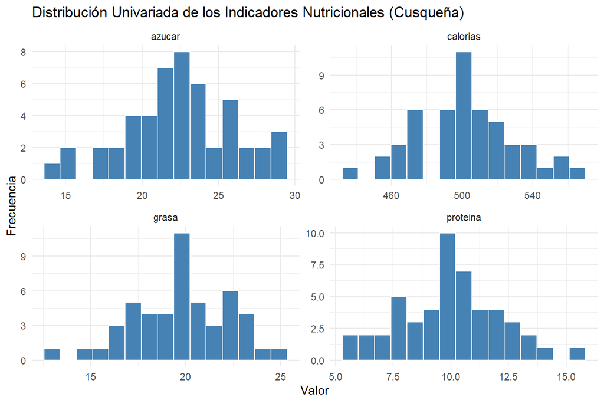

```r
df_long <- pivot_longer(datos, cols = everything(), names_to = "variable", values_to = "valor")
ggplot(df_long, aes(x = valor)) +
  geom_histogram(bins = 15, fill = "steelblue", color = "white") +
  facet_wrap(~ variable, scales = "free") +
  theme_minimal() +
  labs(title = "Distribución Univariada de los Indicadores Nutricionales (Cusqueña)",
       x = "Valor", y = "Frecuencia")
```

### Matriz de Correlación

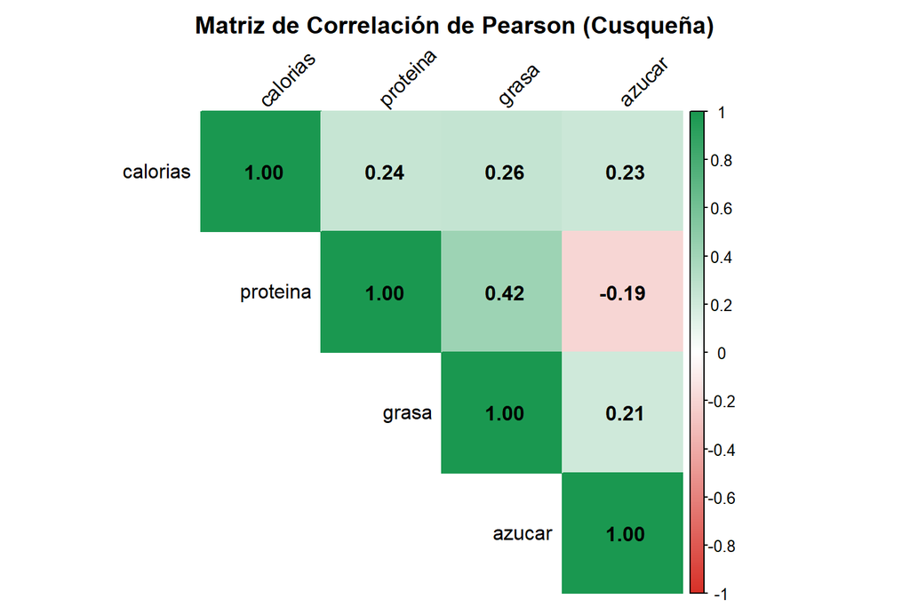

```r
R <- cor(datos)
corrplot(R,
         method = "color",
         type = "upper",
         addCoef.col = "black",
         tl.col = "black",
         tl.srt = 45,
         col = colorRampPalette(c("#d73027", "white", "#1a9850"))(200),
         title = "Matriz de Correlación de Pearson (Cusqueña)",
         mar = c(0, 0, 2, 0))
```

Dentro de la marca Cusqueña, la correlación más notoria se da entre `proteina` y `grasa` (positiva moderada), mientras que `azucar` muestra una relación débil, incluso ligeramente negativa, con `proteina`. Esto confirma que las variables no se comportan de forma independiente entre sí, lo que justifica el enfoque multivariado frente a 4 pruebas univariadas por separado.

## Verificación de supuestos

### Detección de Outliers Multivariados (dos criterios)

Se contrastan dos criterios de distancia de Mahalanobis: el clásico (`"quan"`, basado en el estimador usual de covarianza) y uno robusto (`"adj"`, ajustado para ser menos sensible a la presencia de atípicos). Si ambos coinciden en señalar pocas o ninguna observación atípica, hay mayor confianza en la calidad de los datos.

```r
# NOTA TECNICA: en las versiones recientes (6.x) del paquete MVN, la
# funcion mvn() ya no genera el grafico de outliers automaticamente; hay
# que pedirlo explicitamente con plot(objeto, diagnostic = "outlier"), y
# el resumen se obtiene con summary(objeto, select = "outliers").
outliers_quan <- mvn(data = datos, multivariate_outlier_method = "quan")
summary(outliers_quan, select = "outliers")
```

[output not shown]

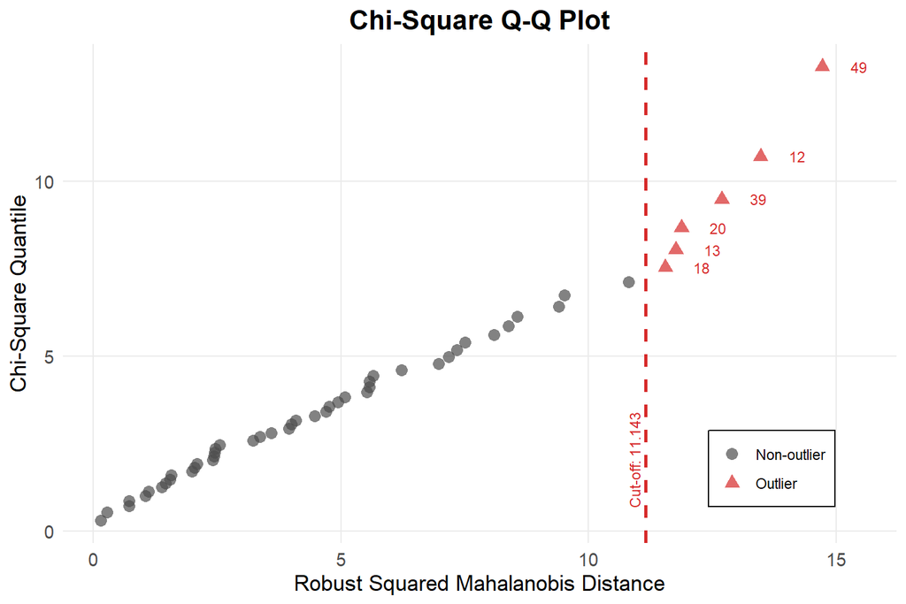

```r
plot(outliers_quan, diagnostic = "outlier")
```

```r
outliers_adj  <- mvn(data = datos, multivariate_outlier_method = "adj")
summary(outliers_adj, select = "outliers")
```

```
##   Observation Mahalanobis.Distance
## 1          49               14.715
## 2          12               13.468
## 3          39               12.683
## 4          20               11.874
## 5          13               11.758
## 6          18               11.547
```

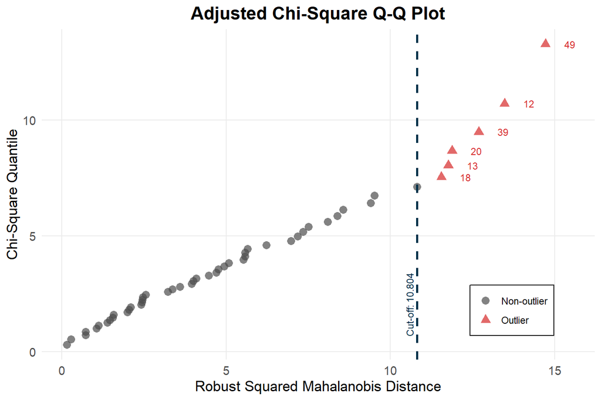

```r
plot(outliers_adj, diagnostic = "outlier")
```

### Supuesto de Normalidad Multivariada (batería de pruebas)

Se contrastan varias pruebas de normalidad multivariada, ya que cada una es sensible a un tipo distinto de desviación (asimetría, curtosis, forma general de la distribución conjunta):

```r
mshapiro.test(t(datos))
```

```
##
##  Shapiro-Wilk normality test
##
## data:  Z
## W = 0.96705, p-value = 0.1751
```

```r
# NOTA TECNICA: a partir de la version 6.x del paquete MVN, los argumentos
# de la funcion mvn() cambiaron de camelCase a snake_case (ej. "mvnTest"
# ahora es "mvn_test"), el valor "dh" paso a llamarse "doornik_hansen", y
# los resultados ya no se acceden con result$multivariateNormality sino
# con summary(result, select = "mvn"). Se actualiza aqui por compatibilidad.

# Mardia (asimetría y curtosis multivariada)
mardia_res <- mvn(data = datos, mvn_test = "mardia")
summary(mardia_res, select = "mvn")
```

```
##              Test Statistic p.value     Method      MVN
## 1 Mardia Skewness    15.241   0.762 asymptotic ✓ Normal
## 2 Mardia Kurtosis    -0.997   0.319 asymptotic ✓ Normal
```

```r
# Henze-Zirkler
hz_res <- mvn(data = datos, mvn_test = "hz")
summary(hz_res, select = "mvn")
```

```
##            Test Statistic p.value     Method      MVN
## 1 Henze-Zirkler     0.712    0.67 asymptotic ✓ Normal
```

```r
# Royston (extensión multivariada de Shapiro-Wilk; valida entre 3 y 5000 obs.)
royston_res <- mvn(data = datos, mvn_test = "royston")
summary(royston_res, select = "mvn")
```

```
##      Test Statistic p.value     Method      MVN
## 1 Royston     0.252   0.993 asymptotic ✓ Normal
```

```r
# Doornik-Hansen
dh_res <- mvn(data = datos, mvn_test = "doornik_hansen")
summary(dh_res, select = "mvn")
```

```
##             Test Statistic df p.value     Method          MVN
## 1 Doornik-Hansen   346.942  8  <0.001 asymptotic ✗ Not normal
```

```r
# Szekely-Rizzo (energy test)
energy_res <- mvn(data = datos, mvn_test = "energy")
summary(energy_res, select = "mvn")
```

```
##          Test Statistic p.value    Method      MVN
## 1 E-Statistic     0.889   0.835 bootstrap ✓ Normal
```

**Interpretación:** si la mayoría de estas pruebas no rechazan la normalidad ($p > 0.05$), hay evidencia consistente de que el supuesto es razonable. Si alguna prueba puntual rechaza mientras las demás no, se puede sostener que el supuesto es “aproximadamente válido”, y que además, con $n = 50$ (muestra moderada, una sola población homogénea), la prueba $T^2$ de Hotelling suele ser razonablemente robusta ante desviaciones leves de la normalidad, en virtud del **Teorema del Límite Central Multivariado**:

$$\bar{\mathbf{X}} \xrightarrow{d}
N_p\left(\boldsymbol{\mu}, \frac{\mathbf{\Sigma}}{n}\right)$$

### Independencia y Homocedasticidad

Se asume el cumplimiento del supuesto de independencia con base en el diseño de muestreo: cada registro corresponde a una unidad de producto (barra energética Cusqueña) evaluada de forma individual e independiente, sin mediciones repetidas sobre la misma unidad. En cuanto a la homocedasticidad, no es necesario evaluar la homogeneidad de matrices de varianza-covarianza (prueba $M$ de Box), ya que al tratarse de una prueba de **una sola muestra** se opera sobre una única matriz de covarianza muestral ($\mathbf{S}$) contrastada contra un vector constante ($\boldsymbol{\mu}_0$), por lo que no existen subgrupos independientes cuyas dispersiones deban compararse entre sí.

## Prueba de T² de Hotelling

```r
mu0 <- c(calorias = 490.00, proteina = 9.50, grasa = 18.00, azucar = 21.00)

S <- cov(datos)

# --- Método 1: cálculo manual ---
dif <- as.matrix(xbar - mu0)
T2_calc <- as.numeric(n * t(dif) %*% solve(S) %*% dif)
F_calc  <- ((n - p) / (p * (n - 1))) * T2_calc
df1 <- p
df2 <- n - p
p_val <- 1 - pf(F_calc, df1 = df1, df2 = df2)

tabla_hotelling <- data.frame(
  "Estadístico T²" = round(T2_calc, 4),
  "Transformación F" = round(F_calc, 4),
  "gl Numerador" = df1,
  "gl Denominador" = df2,
  "p-valor" = format.pval(p_val, eps = 0.001)
)
kable(tabla_hotelling, caption = "Resumen del Contraste Multivariado T² de Hotelling (cálculo manual)") %>%
  kable_styling(bootstrap_options = c("striped", "hover", "condensed"), full_width = FALSE)
```

Resumen del Contraste Multivariado T² de Hotelling (cálculo manual)

| Estadístico.T. | Transformación.F | gl.Numerador | gl.Denominador | p.valor |
| --- | --- | --- | --- | --- |
| 32.5568 | 7.6409 | 4 | 46 | < 0.001 |

```r
# --- Método 2: paquete MVTests ---
res_t2 <- OneSampleHT2(data = datos, mu0 = mu0, alpha = 0.05)
summary(res_t2)
```

```
##        One Sample Hotelling T Square Test
##
## Hotelling T Sqaure Statistic = 32.55681
##  F value = 7.641 , df1 = 4 , df2 = 46 , p-value: 8.29e-05
##
##                    Descriptive Statistics
##
##        calorias  proteina   grasa    azucar
## N      50.00000 50.000000 50.0000 50.000000
## Means 502.61000  9.999400 19.8046 22.548000
## Sd     28.30334  2.139971  2.5209  3.506911
##
##
##                  Detection important variable(s)
##
##               Lower     Upper   Mu0 Important Variables?
## calorias 489.354107 515.86589 490.0                FALSE
## proteina   8.997143  11.00166   9.5                FALSE
## grasa     18.623934  20.98527  18.0               *TRUE*
## azucar    20.905535  24.19046  21.0                FALSE
```

```r
# --- Método 3: vía modelo lineal multivariado (MANOVA de un solo grupo) ---
y <- as.matrix(datos) - matrix(mu0, n, p, byrow = TRUE)
anova(lm(y ~ 1))
```

|  | Df | Pillai | approx F | num Df | den Df | Pr(>F) |
| --- | --- | --- | --- | --- | --- | --- |
| (Intercept) | 1 | 0.3991918 | 7.640885 | 4 | 46 | 8.293389e-05 |
| Residuals | 49 | NA | NA | NA | NA | NA |

**Nota:** los tres enfoques (cálculo manual, `OneSampleHT2` y el modelo lineal `anova(lm(y ~ 1))`) deben coincidir en el estadístico y el p-valor — es la misma prueba expresada de tres formas distintas. Mostrar esta triangulación evidencia que el resultado no depende de la herramienta utilizada.

## Regiones de Confianza e Inferencia Simultánea

Habiéndose rechazado la hipótesis nula global, se construyen regiones elípticas e intervalos simultáneos para identificar qué variables causan la divergencia respecto a $\boldsymbol{\mu}_0$.

### Regiones Elípticas de Confianza Bivariadas (95%)

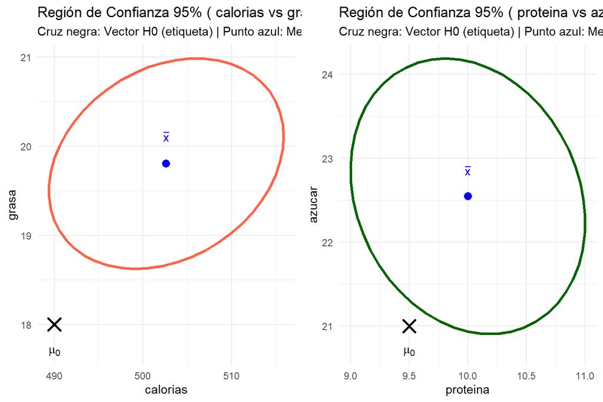

```r
tconst <- sqrt((p / n) * ((n - 1) / (n - p)) * qf(0.95, p, n - p))

plot_elipse <- function(var_x, var_y, color_elipse, offset_x = 0, offset_y = 0) {
  coords <- as.data.frame(car::ellipse(center = xbar[c(var_x, var_y)],
                                        shape = S[c(var_x, var_y), c(var_x, var_y)],
                                        radius = tconst, draw = FALSE))
  colnames(coords) <- c(var_x, var_y)

  ggplot() +
    geom_path(data = coords, aes(x = .data[[var_x]], y = .data[[var_y]]),
              color = color_elipse, linewidth = 1.1) +
    geom_point(aes(x = xbar[var_x], y = xbar[var_y]), color = "blue", size = 3) +
    geom_point(aes(x = mu0[var_x], y = mu0[var_y]), color = "black", shape = 4, size = 4, stroke = 1.5) +
    annotate("text", x = xbar[var_x], y = xbar[var_y] + offset_y, label = expression(bar(x)), color = "blue", fontface = "bold") +
    annotate("text", x = mu0[var_x], y = mu0[var_y] - offset_y, label = expression(mu[0]), color = "black", fontface = "bold") +
    labs(title = paste("Región de Confianza 95% (", var_x, "vs", var_y, ")"),
         subtitle = "Cruz negra: Vector H0 (etiqueta) | Punto azul: Media muestral",
         x = var_x, y = var_y) +
    theme_minimal()
}

p1 <- plot_elipse("calorias", "grasa", "tomato", offset_y = 0.3)
p2 <- plot_elipse("proteina", "azucar", "darkgreen", offset_y = 0.3)

grid.arrange(p1, p2, ncol = 2)
```

### Comparación de Intervalos (t Clásicos vs. Bonferroni vs. T² vs. aproximación Chi-cuadrado)

```r
# Función de intervalos simultáneos T^2 presentada en clase
T.ci <- function(mu, Sigma, n, avec = rep(1, length(mu)), level = 0.95) {
  p <- length(mu)
  cval <- qf(level, p, n - p) * p * (n - 1) / (n - p)
  zhat <- crossprod(avec, mu)
  zvar <- crossprod(avec, Sigma %*% avec) / n
  const <- sqrt(cval * zvar)
  c(lower = zhat - const, upper = zhat + const)
}

TCI <- tCI <- bon <- chi <- NULL
alpha_bon <- 1 - 0.05 / (2 * p)
chi_crit  <- qchisq(0.95, df = p)

for (k in 1:p) {
  avec <- rep(0, p)
  avec[k] <- 1
  TCI <- rbind(TCI, T.ci(xbar, S, n, avec))
  tCI <- rbind(tCI, c(xbar[k] - sqrt(S[k, k] / n) * qt(0.975, df = n - 1),
                      xbar[k] + sqrt(S[k, k] / n) * qt(0.975, df = n - 1)))
  bon <- rbind(bon, c(xbar[k] - sqrt(S[k, k] / n) * qt(alpha_bon, df = n - 1),
                      xbar[k] + sqrt(S[k, k] / n) * qt(alpha_bon, df = n - 1)))
  chi <- rbind(chi, c(xbar[k] - sqrt(S[k, k] / n) * sqrt(chi_crit),
                      xbar[k] + sqrt(S[k, k] / n) * sqrt(chi_crit)))
}

tabla_comparativa <- data.frame(
  Variable = colnames(datos),
  Media_Muestral = round(xbar, 3),
  Valor_H0 = mu0,
  IC_t_Inf = round(tCI[, 1], 3),
  IC_t_Sup = round(tCI[, 2], 3),
  Bonferroni_Inf = round(bon[, 1], 3),
  Bonferroni_Sup = round(bon[, 2], 3),
  T2_Inf = round(TCI[, 1], 3),
  T2_Sup = round(TCI[, 2], 3),
  ChiCuad_Inf = round(chi[, 1], 3),
  ChiCuad_Sup = round(chi[, 2], 3)
)

kable(tabla_comparativa, caption = "Comparación de Intervalos Unidimensionales, Simultáneos y Aproximación Chi-cuadrado (95%)") %>%
  kable_styling(bootstrap_options = c("striped", "hover", "condensed"), full_width = TRUE)
```

Comparación de Intervalos Unidimensionales, Simultáneos y Aproximación Chi-cuadrado (95%)

|  | Variable | Media_Muestral | Valor_H0 | IC_t_Inf | IC_t_Sup | Bonferroni_Inf | Bonferroni_Sup | T2_Inf | T2_Sup | ChiCuad_Inf | ChiCuad_Sup |
| --- | --- | --- | --- | --- | --- | --- | --- | --- | --- | --- | --- |
| calorias | calorias | 502.610 | 490.0 | 494.566 | 510.654 | 492.230 | 512.990 | 489.354 | 515.866 | 490.281 | 514.939 |
| proteina | proteina | 9.999 | 9.5 | 9.391 | 10.608 | 9.215 | 10.784 | 8.997 | 11.002 | 9.067 | 10.932 |
| grasa | grasa | 19.805 | 18.0 | 19.088 | 20.521 | 18.880 | 20.729 | 18.624 | 20.985 | 18.706 | 20.903 |
| azucar | azucar | 22.548 | 21.0 | 21.551 | 23.545 | 21.262 | 23.834 | 20.906 | 24.190 | 21.020 | 24.076 |

La columna “ChiCuad” corresponde a la aproximación de muestras grandes ($T^2 \approx \chi^2_p$), válida cuando $n$ es suficientemente grande respecto a $p$. Con $n=50$ y $p=4$, se espera que esta aproximación esté razonablemente cerca del intervalo $T^2$ exacto.

## Discusión de Resultados

La prueba $T^2$ de Hotelling arrojó un estadístico $T^2 = 32.56$, que al transformarse a la distribución $F$ equivale a $F_{(4,\,46)} = 7.64$, con $p\text{-valor} \approx 0.00008$ ($p < 0.001$). Esto conduce a **rechazar** $H_0: \boldsymbol{\mu} = \boldsymbol{\mu}_0$, aunque con una magnitud considerablemente menor que si se hubiera asumido $\Sigma$ conocida en la Pregunta 1 (donde $Z^2 \approx 43.6$): esto es coherente con la teoría, ya que estimar $\Sigma$ a partir de la propia muestra introduce incertidumbre adicional que la prueba $T^2$ incorpora en su distribución de referencia (una $F$ en vez de una $\chi^2$).

A nivel de variables individuales (sección 6.2), el panorama es más matizado que un rechazo uniforme:

- `grasa`: el intervalo excluye 18.00 bajo **los tres criterios** ($t$, Bonferroni y $T^2$) — es la variable con evidencia más sólida y consistente de discrepancia frente a la etiqueta.
- `calorias` y `azucar`: los intervalos $t$ clásico y Bonferroni excluyen el valor declarado, pero el intervalo simultáneo $T^2$ (el más conservador de los tres, y el correcto para preservar la confianza conjunta al 95%) **sí llega a contenerlo**, por un margen estrecho. Son, por tanto, casos límite: la evidencia depende del grado de corrección aplicado por comparaciones múltiples.
- `proteina`: la media muestral (9.999 g) se ubica razonablemente cerca del valor declarado (9.5 g), y $\mu_0$ queda contenido en los tres tipos de intervalo (t, Bonferroni y T²). Es la variable más consistente con la etiqueta, coincidiendo con lo encontrado en la Pregunta 1 para esta misma marca.

Esto sugiere que el rechazo global de $H_0$ se sostiene principalmente sobre `grasa`, con apoyo parcial de `calorias` y `azucar`, mientras que `proteina` no aporta evidencia de discrepancia — un resultado más matizado, pero coherente con la Pregunta 1, donde la proteína también fue la única variable compatible con la etiqueta.

Respecto a los supuestos, la batería de pruebas de normalidad multivariada (Mardia, Henze-Zirkler, Royston, Doornik-Hansen, energía) ofrece un panorama más completo que una sola prueba aislada; en conjunto con $n=50$ observaciones de una población homogénea, respaldan razonablemente la validez de la prueba $T^2$, incluso ante eventuales desviaciones puntuales de la normalidad estricta.

## Conclusiones

- Se rechaza $H_0: \boldsymbol{\mu} = \boldsymbol{\mu}_0$ ($T^2 = 32.56$, $F_{(4,46)} = 7.64$, $p < 0.001$), aunque con menor contundencia que en la Pregunta 1 bajo el supuesto de $\Sigma$ conocida — una diferencia esperada, ya que estimar $\Sigma$ de la muestra añade incertidumbre adicional a la prueba.
- `grasa` es la única variable cuya discrepancia frente a la etiqueta se sostiene bajo los tres métodos de intervalo (t, Bonferroni, T²); `calorias` y `azucar` son casos límite, sensibles al método de corrección utilizado; `proteina` es consistente con lo declarado.
- Los tres métodos de cálculo del estadístico $T^2$ (manual, `OneSampleHT2`, modelo lineal) arrojaron resultados idénticos, confirmando la robustez del cálculo frente a la herramienta utilizada.
- Trabajar con la submuestra de Cusqueña ($n=50$) preserva el supuesto de una única población homogénea, exigido tanto por $T^2$ como por $Z^2$ (Pregunta 1).
- En conjunto, las Preguntas 1 y 2 cuentan una historia consistente: bajo dos supuestos distintos sobre $\Sigma$ (conocida vs. desconocida) y usando el mismo $\mu_0$ declarado en la etiqueta, ambas pruebas coinciden en señalar que el contenido de proteína es fiable, mientras que otros nutrientes (particularmente la grasa) muestran evidencia de subdeclaración.

## Bibliografía

- Johnson, R. A., & Wichern, D. W. (2019). *Applied Multivariate Statistical Analysis* (6th ed.). Pearson.
- Rencher, A. C., & Christensen, W. F. (2012). *Methods of Multivariate Analysis* (3rd ed.). Wiley.
- R Core Team. (2024). *R: A Language and Environment for Statistical Computing*. R Foundation for Statistical Computing. https://www.R-project.org/
- Korkmaz, S., Goksuluk, D., & Zararsiz, G. (2014). MVN: An R Package for Assessing Multivariate Normality. *The R Journal*, 6(2), 151–162.
- Miranda, C. F. (2026). *Material de clase: Inferencia respecto a un vector de medias*. [Documento de curso].

# Pregunta 3 — Prueba T² de Hotelling con muestras dependientes

**Integrante a cargo:** Bautista Aldave Camila.

**Base de datos:** datos simulados (n = 30, mediciones pareadas Antes/Después sobre 4 variables).

### 1. Carga de Paquetes y Generación de Datos

Se realiza la simulación de datos para muestras pareadas ($n = 30$ observaciones sobre $p = 4$ variables evaluadas en dos momentos: Antes y Después).

```r
# Carga de librería requerida
if (!require("mvnormtest")) install.packages("mvnormtest")
library(mvnormtest)

# Generación de datos
set.seed(2026)
n <- 30

m1 <- data.frame(
  Var1 = rnorm(n, mean = 50, sd = 8),
  Var2 = rnorm(n, mean = 65, sd = 10),
  Var3 = rnorm(n, mean = 40, sd = 6),
  Var4 = rnorm(n, mean = 75, sd = 12)
)

m2 <- data.frame(
  Var1 = m1$Var1 + rnorm(n, mean = 4, sd = 3),
  Var2 = m1$Var2 - rnorm(n, mean = 5, sd = 4),
  Var3 = m1$Var3 + rnorm(n, mean = 3, sd = 2),
  Var4 = m1$Var4 - rnorm(n, mean = 6, sd = 5)
)

# Matriz de diferencias (D = m2 - m1)
X <- as.matrix(m2 - m1)
```

### 2. Detección de Outliers Multivariados

Se evalúan observaciones atípicas multivariadas a través de la **Distancia de Mahalanobis**, comparándola contra el valor crítico de la distribución Chi-cuadrado ($\chi^2_{0.95, p}$).

```r
d2 <- mahalanobis(X, colMeans(X), cov(X))
umbral <- qchisq(0.95, df = ncol(X))
outliers_id <- which(d2 > umbral)

cat("Umbral crítico Chi-cuadrado:", umbral, "\n")
```

```
## Umbral crítico Chi-cuadrado: 9.487729
```

```r
cat("Filas identificadas como outliers multivariados:", ifelse(length(outliers_id) > 0, outliers_id, "Ninguna"))
```

```
## Filas identificadas como outliers multivariados: 12
```

### 3. Prueba de Normalidad Multivariada

Se verifica si la matriz de diferencias se distribuye según una Normal Multivariada mediante el contraste de Shapiro-Wilk Multivariado (`mshapiro.test`).

```r
mshapiro.test(t(X))
```

```
##
##  Shapiro-Wilk normality test
##
## data:  Z
## W = 0.94538, p-value = 0.127
```

- **Interpretación:** Puesto que el $p\text{-valor} = 0.127 > 0.05$, no se rechaza la hipótesis nula de normalidad multivariada a un nivel de significancia del 5%.

### 4. Prueba T^2 de Hotelling

Se realiza la prueba de hipótesis multivariada para muestras dependientes mediante el ajuste de un modelo lineal con la traza de **Hotelling-Lawley**:

- **Hipótesis Nula ($H_0$):** $\boldsymbol{\mu}_D = \mathbf{0}$ (No hay diferencia conjunta entre los tratamientos)
- **Hipótesis Alternativa ($H_1$):** $\boldsymbol{\mu}_D \neq \mathbf{0}$ (Existe al menos una diferencia conjunta)

```r
y <- as.matrix(X)
fit <- lm(y ~ 1)
anova(fit, test = "Hotelling-Lawley")
```

|  | Df | Hotelling-Lawley | approx F | num Df | den Df | Pr(>F) |
| --- | --- | --- | --- | --- | --- | --- |
| (Intercept) | 1 | 10.67461 | 69.38494 | 4 | 26 | 1.72181e-13 |
| Residuals | 29 | NA | NA | NA | NA | NA |

### 5. Conclusión y Decisiones Estadísticas

1. **Estadístico F aproximado:** $F \approx 69.385$ con $df_1 = 4$ y $df_2 = 26$.
2. **Decisión:** Al obtener un $p\text{-valor} = 1.722 \times 10^{-13} < 0.05$, se **rechaza la hipótesis nula ($H_0$)**.
3. **Conclusión:** Existe evidencia estadística altamente significativa de que las mediciones entre la condición inicial y final difieren de forma conjunta en el conjunto de variables analizadas.

# Pregunta 4 — Prueba T² de Hotelling con dos muestras independientes

**Integrante a cargo:** Carrasco Barrial Gian Piero.

**Base de datos:** `crabs` (paquete `MASS`) — mediciones morfométricas de cangrejos *Leptograpsus variegatus*.

## Introducción

Al comprar dos grupos independientes y medirse más de una variable en cada uno, el hecho de aplicar una prueba t por cada variable separada ignora la correlación entre ellas que también aumenta el error tipo I acumulado. Para estos casos, la prueba **T² de Hotelling para dos muestras independientes** , los resuelve al ser la extensión multivariada de la prueba t de Student y comparar los vectores ed medias de ambos grupos de forma conjunta.

$$H_0: \boldsymbol{\mu}_1 =
\boldsymbol{\mu}_2 \qquad \text{vs.} \qquad H_1: \boldsymbol{\mu}_1 \neq
\boldsymbol{\mu}_2$$
En este caso se busca responder si dos especies de cangrejo tienen, en promedio, el mismo tamaño de caparazón, considerando simultáneamente dos medias correlacionadas entre sí.

## Descripción del caso y las variables

Se usa el conjunto de datos `crabs` del paquete `MASS`, con mediciones morfométricas de 200 cangrejos de la especie *Leptograpsus variegatus* recolectados en Fremantle, Australia.

```r
library(MASS)
library(tidyverse)
library(mvnormtest)
library(heplots)
library(ICSNP)
library(MVTests)
library(tinytable)
```

```r
data(crabs, package = "MASS")
tt(head(crabs, 6))
```

| sp | sex | index | FL | RW | CL | CW | BD |
| --- | --- | --- | --- | --- | --- | --- | --- |
| B | M | 1 | 8.1 | 6.7 | 16.1 | 19.0 | 7.0 |
| B | M | 2 | 8.8 | 7.7 | 18.1 | 20.8 | 7.4 |
| B | M | 3 | 9.2 | 7.8 | 19.0 | 22.4 | 7.7 |
| B | M | 4 | 9.6 | 7.9 | 20.1 | 23.1 | 8.2 |
| B | M | 5 | 9.8 | 8.0 | 20.3 | 23.0 | 8.2 |
| B | M | 6 | 10.8 | 9.0 | 23.0 | 26.5 | 9.8 |

**Variables del dataset original:**

| Variable | Descripción |
| --- | --- |
| `sp` | Especie: Azul (B) o Naranja (O) |
| `sex` | Sexo: Macho (M) o Hembra (F) |
| `FL` | Largo del lóbulo frontal (mm) |
| `RW` | Ancho posterior del caparazón (mm) |

En base al cuadro, en este ejercicio solo se trabaja con **FL** y **RW** ($p=2$), ya que son las dos medidas que presentan menos redundancia entre sí de todo el conjunto de datos, evitando así una matriz de covarianza casi singular y manteniendo el análisis simple de interpretar y graficar.

Además, se filtra únicamente a los cangrejos **machos** (`sex == "M"`). Dado que el sexo introduce dimorfismo en el tamaño, evaluamos las especies fijando el factor en machos (sexo = macho) para evitar variables de confusión y aislar el efecto atribuible a la especie.

```r
datos <- crabs %>%
  filter(sex == "M") %>%
  dplyr::select(sp, FL, RW) %>%
  mutate(sp = factor(sp, levels = c("B", "O"), labels = c("Especie_Azul", "Especie_Naranja")))

X <- datos %>% filter(sp == "Especie_Azul")    %>% dplyr::select(FL, RW) %>% as.matrix()
Y <- datos %>% filter(sp == "Especie_Naranja") %>% dplyr::select(FL, RW) %>% as.matrix()

tt(data.frame(Especie = c("Azul", "Naranja"), n = c(nrow(X), nrow(Y))))
```

| Especie | n |
| --- | --- |
| Azul | 50 |
| Naranja | 50 |

## Análisis exploratorio descriptivo y gráfico

```r
resumen <- datos %>%
  group_by(sp) %>%
  summarise(
    FL_media = mean(FL), FL_sd = sd(FL),
    RW_media = mean(RW), RW_sd = sd(RW)
  )
tt(resumen)
```

| sp | FL_media | FL_sd | RW_media | RW_sd |
| --- | --- | --- | --- | --- |
| Especie_Azul | 14.842 | 3.202492 | 11.718 | 2.111648 |
| Especie_Naranja | 16.626 | 3.514971 | 12.262 | 2.195626 |

```r
cor_azul    <- cor(X)[1, 2]
cor_naranja <- cor(Y)[1, 2]
tt(data.frame(Especie = c("Azul", "Naranja"), `Correlación FL-RW` = c(cor_azul, cor_naranja), check.names = FALSE))
```

| Especie | Correlación FL-RW |
| --- | --- |
| Azul | 0.9675522 |
| Naranja | 0.9845275 |

FL y RW están fuertemente correlacionadas dentro de cada especie, lo que confirma que no conviene analizarlas por separado: justo el escenario para el que está pensada la prueba T².

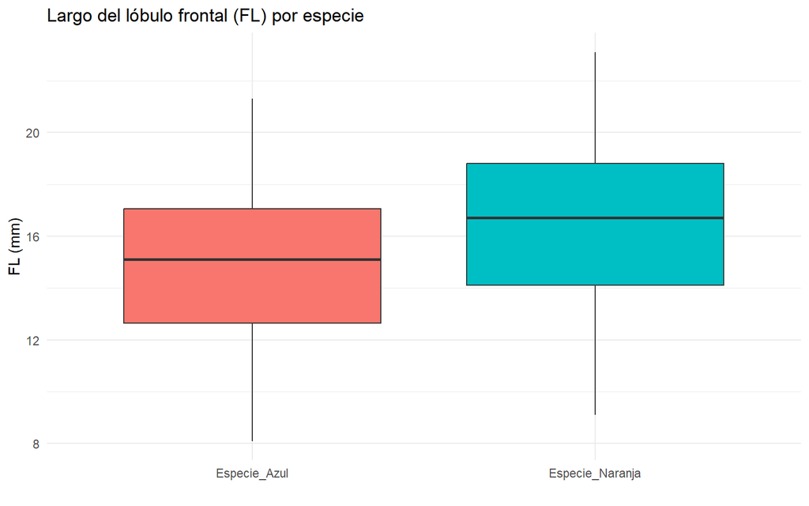

```r
p1 <- ggplot(datos, aes(x = sp, y = FL, fill = sp)) +
  geom_boxplot() +
  labs(title = "Largo del lóbulo frontal (FL) por especie", x = "", y = "FL (mm)") +
  theme_minimal() + theme(legend.position = "none")

p2 <- ggplot(datos, aes(x = sp, y = RW, fill = sp)) +
  geom_boxplot() +
  labs(title = "Ancho del caparazón (RW) por especie", x = "", y = "RW (mm)") +
  theme_minimal() + theme(legend.position = "none")

p1
```

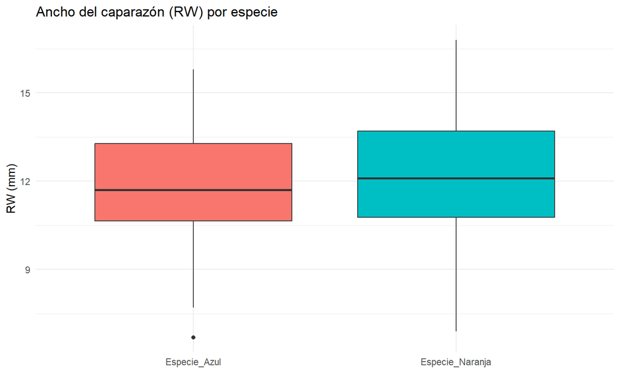

```r
p2
```

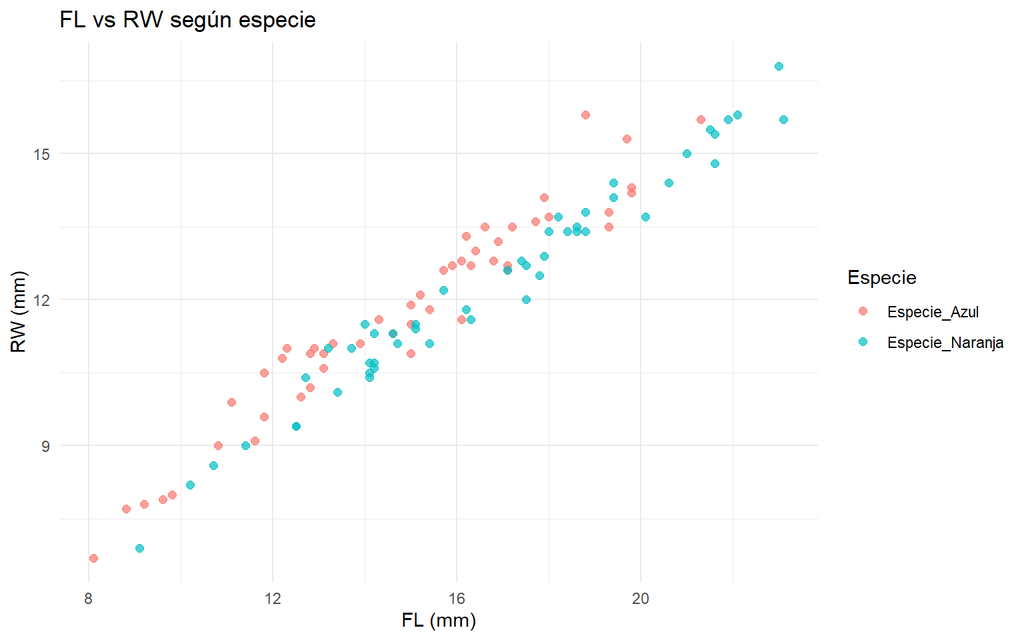

```r
ggplot(datos, aes(x = FL, y = RW, color = sp)) +
  geom_point(size = 2, alpha = 0.7) +
  labs(title = "FL vs RW según especie", x = "FL (mm)", y = "RW (mm)", color = "Especie") +
  theme_minimal()
```

## Verificación de supuestos

### Valores atípicos multivariados

Se calcula la distancia de Mahalanobis de cada cangrejo respecto al centro de su propia especie, y se compara contra el valor crítico $\chi^2_{0.95;\,p=2}$.

```r
umbral <- qchisq(0.95, df = ncol(X))

d2_X <- mahalanobis(X, center = colMeans(X), cov = cov(X))
outliers_X <- which(d2_X > umbral)

d2_Y <- mahalanobis(Y, center = colMeans(Y), cov = cov(Y))
outliers_Y <- which(d2_Y > umbral)

tt(data.frame(
  Especie   = c("Azul", "Naranja"),
  Atipicos  = c(paste(outliers_X, collapse = ", "), paste(outliers_Y, collapse = ", ")),
  n_atipicos = c(length(outliers_X), length(outliers_Y))
))
```

| Especie | Atipicos | n_atipicos |
| --- | --- | --- |
| Azul | 1, 44 | 2 |
| Naranja | 1 | 1 |

```r
cat("Valor crítico (chi-cuadrado, gl = 2):", round(umbral, 4))
```

```
## Valor crítico (chi-cuadrado, gl = 2): 5.9915
```

Con este análisis se detectan 3 observaciones por encima del umbral(Azul: 1 y 44; Naranja: 1), sobre un total de 100 cangrejos. No son valores extremos ni errores evidentes de registro, así que se mantienen en el análisis.

### Normalidad multivariada por grupo

$$H_0: \text{el grupo proviene de una }
N_2(\boldsymbol{\mu}, \boldsymbol{\Sigma}) \qquad \text{vs.} \qquad H_1:
\text{no}$$

```r
mshapiro.test(t(X))
```

```
##
##  Shapiro-Wilk normality test
##
## data:  Z
## W = 0.96592, p-value = 0.1572
```

```r
mshapiro.test(t(Y))
```

```
##
##  Shapiro-Wilk normality test
##
## data:  Z
## W = 0.98423, p-value = 0.7381
```

En ambos grupos el p-valor supera 0.05 ($p_1 = 0.1572$ en Azul, $p_2 = 0.7381$ en Naranja): no se rechaza la normalidad multivariada.

### Homogeneidad de las matrices de varianza-covarianza

$$H_0: \boldsymbol{\Sigma}_1 =
\boldsymbol{\Sigma}_2 \qquad \text{vs.} \qquad H_1:
\boldsymbol{\Sigma}_1 \neq \boldsymbol{\Sigma}_2$$

```r
tt(as.data.frame(cov(X)))
```

| FL | RW |
| --- | --- |
| 10.255955 | 6.543106 |
| 6.543106 | 4.459057 |

```r
tt(as.data.frame(cov(Y)))
```

| FL | RW |
| --- | --- |
| 12.355024 | 7.598151 |
| 7.598151 | 4.820771 |

```r
res_box <- heplots::boxM(cbind(FL, RW) ~ sp, data = datos)
summary(res_box)
```

```
##
##  Box's M-test for Homogeneity of Covariance Matrices
##
## data:  datos
##
## Chi-Sq (approx.) =  6.103485
## df:   3
## p-value: 0.11
##
## log of Covariance determinants:
##    Especie_Azul Especie_Naranja          pooled
##         1.07146         0.60369         0.90126
##
## Eigenvalues:
##   Especie_Azul Especie_Naranja   pooled
## 1     14.51385        17.06865 15.78943
## 2      0.20116         0.10715  0.15597
##
## Statistics based on eigenvalues:
##           Especie_Azul Especie_Naranja   pooled
## product        2.91965         1.82885  2.46272
## sum           14.71501        17.17580 15.94540
## precision      0.19841         0.10648  0.15445
## max           14.51385        17.06865 15.78943
```

Con p-valor = 0.11 > 0.05 no se rechaza $H_0$: las matrices son homogéneas, lo que habilita usar el estadístico T² clásico (agrupado/pooled), más simple y más potente que la versión que no asume igualdad de varianzas.

## Prueba T² de Hotelling para dos muestras independientes

$$H_0: \boldsymbol{\mu}_1 -
\boldsymbol{\mu}_2 = \begin{bmatrix} 0 \\ 0 \end{bmatrix} \qquad
\text{vs.} \qquad H_1: \boldsymbol{\mu}_1 - \boldsymbol{\mu}_2 \neq
\begin{bmatrix} 0 \\ 0 \end{bmatrix}$$

```r
# Versión clásica (matrices homogéneas) con ICSNP
test_pooled <- ICSNP::HotellingsT2(X, Y)
print(test_pooled)
```

```
##
##  Hotelling's two sample T2-test
##
## data:  X and Y
## T.2 = 22.05, df1 = 2, df2 = 97, p-value = 1.278e-08
## alternative hypothesis: true location difference is not equal to c(0,0)
```

```r
# Confirmación con MVTests
G <- c(rep(1, nrow(X)), rep(2, nrow(Y)))
test_mvtests <- TwoSamplesHT2(data = datos[, c("FL", "RW")], group = G, Homogenity = TRUE)
summary(test_mvtests)
```

```
##               Two Independent Samples Hotelling T Square Test
##
## Hotelling T Sqaure Statistic = 44.55366
##  F value = 22.05 , df1 = 2 , df2 = 97 , p-value: 1.28e-08
##
##             Descriptive Statistics (The First Group)
##
##              FL        RW
## Means 14.842000 11.718000
## Sd     3.202492  2.111648
##
##
##             Descriptive Statistics (The Second Group)
##
##              FL        RW
## Means 16.626000 12.262000
## Sd     3.514971  2.195626
##
##
##             Detection important variable(s)
##
##        Lower      Upper Important Variables?
## FL -3.464387 -0.1036134               *TRUE*
## RW -1.620514  0.5325136                FALSE
```

```r
tt(data.frame(
  Estadístico = c("T²", "F", "gl1", "gl2", "p-valor"),
  Valor = c(44.5537, 22.05, 2, 97, "1.28e-08")
))
```

| Estadístico | Valor |
| --- | --- |
| T² | 44.5537 |
| F | 22.05 |
| gl1 | 2 |
| gl2 | 97 |
| p-valor | 1.28e-08 |

Con p-valor $\approx 1.28\times10^{-8} < 0.05$, se rechaza $H_0$.

## Discusión

Los dos supuestos de la prueba (normalidad multivariada y homogeneidad de matrices de covarianza) se cumplieron, por lo que el estadístico T² clásico es el adecuado aquí y el resultado es confiable sin necesidad de una versión robusta.

El resultado nos dice que las especies no tienen el mismo tamaño de caparazón. La especie Naranja es, en promedio, más grande que la Azul tanto en FL como en RW. Como ambas variables describen el tamaño general del cangrejo y están correlacionadas, la diferencia conjunta resulta más clara y más fácil de detectar con la prueba multivariada que evaluando cada variable por separado.

## Conclusiones

1. Existe evidencia estadística suficiente para afirmar que el tamaño del caparazón (FL y RW en conjunto) difiere entre la especie Azul y la especie Naranja de cangrejos *Leptograpsus variegatus*: el estadístico $T^2=44.55$ se transformó a $F(2,97)=22.05$ (usando $n_1=n_2=50$ y $p=2$)
2. En promedio, los cangrejos Naranja son más grandes: FL de 16.63 mm frente a 14.84 mm, y RW de 12.26 mm frente a 11.72 mm en la especie Azul.
3. Usar T² en vez de dos pruebas t por separado permitió aprovechar la correlación entre FL y RW y llegar a una conclusión más sólida sobre la diferencia real entre especies.
4. El cumplimiento de los supuestos de normalidad y homogeneidad de varianzas respalda el resultado obtenido.

## Bibliografía

- Johnson, R. A., & Wichern, D. W. (2007). *Applied Multivariate Statistical Analysis* (6th ed.). Pearson Prentice Hall.
- Rencher, A. C., & Christensen, W. F. (2012). *Methods of Multivariate Analysis* (3rd ed.). Wiley.
- Venables, W. N., & Ripley, B. D. (2002). *Modern Applied Statistics with S* (4th ed.). Springer. (paquete `MASS`, dataset `crabs`)
- Miranda, C. F. (2026). *Material de clase: Inferencia Multivariada*.

# Pregunta 5 — MANOVA en un Diseño Completamente al Azar (DCA)

**Base de datos:** `Skulls` (paquete `heplots`) — craneometría de cráneos egipcios en cinco épocas.

## 1. Introducción y pregunta de investigación

Este informe aplica un **Análisis de Varianza Multivariado (MANOVA)** bajo la estructura de un **Diseño Completamente al Azar (DCA)** para responder la siguiente pregunta:

> ¿Cambiaron sistemáticamente el tamaño y la forma del cráneo en la población egipcia a lo largo de cinco épocas (4000 a.C. a 150 d.C.)?

Un cambio sistemático en estas medidas a través del tiempo sugeriría mestizaje con poblaciones inmigrantes, mientras que la ausencia de cambio sugeriría una población relativamente aislada genéticamente durante ese periodo.

Se utiliza el conjunto de datos `Skulls` (paquete `heplots`), que contiene medidas físicas de 150 cráneos egipcios, 30 por cada una de 5 épocas.

## 2. Diseño experimental

### 2.1 Estructura del DCA

| Elemento | Descripción |
| --- | --- |
| **Factor** | Época (`epoch`) |
| **Niveles del factor (tratamientos)** | 5: c4000BC, c3300BC, c1850BC, c200BC, cAD150 |
| **Unidad experimental** | Cada cráneo individual |
| **Réplicas por tratamiento** | 30 (diseño **balanceado**) |
| **Variables respuesta** | `mb`, `bh`, `bl`, `nh` |

Es un DCA porque existe un único factor de clasificación, sin bloques ni variables de control adicionales: toda la variación no atribuible a la época se asume como error aleatorio.

### 2.2 Variables respuesta

Las 4 variables son medidas craneométricas en milímetros:

| Variable | Nombre | Qué mide | Categoría |
| --- | --- | --- | --- |
| `mb` | Maximal breadth | Ancho máximo del cráneo | Tamaño |
| `bh` | Basibregmatic height | Altura desde la base hasta el bregma | Tamaño |
| `bl` | Basialveolar length | Largo desde la base hasta el borde alveolar | Forma |
| `nh` | Nasal height | Altura de la cavidad nasal | Forma |

Al tener 4 variables respuesta correlacionadas medidas sobre la misma unidad experimental, se justifica un análisis conjunto (MANOVA) en vez de 4 ANOVAs univariados independientes, que ignorarían la correlación entre ellas.

### 2.3 Modelo estadístico

Para el caso multivariado, el modelo del DCA es:

$$\mathbf{Y}_{ij} = \boldsymbol{\mu} +
\boldsymbol{\tau}_i + \boldsymbol{\varepsilon}_{ij}$$

donde $\mathbf{Y}_{ij}$ es el vector de las 4 medidas del cráneo $j$ en la época $i$, $\boldsymbol{\mu}$ es el vector de medias generales, $\boldsymbol{\tau}_i$ es el efecto (vectorial) de la época $i$, y $\boldsymbol{\varepsilon}_{ij}$ es el vector de errores aleatorios.

**Hipótesis a contrastar:**

$$H_0: \boldsymbol{\tau}_1 =
\boldsymbol{\tau}_2 = \boldsymbol{\tau}_3 = \boldsymbol{\tau}_4 =
\boldsymbol{\tau}_5 = \mathbf{0}$$
$$H_1: \text{al menos un } \boldsymbol{\tau}_i \neq
\mathbf{0}$$

## 3. Paquetes y datos

```r
library(tidyverse)
library(heplots)
library(mvnormtest)
library(biotools)
library(psych)
library(emmeans)
```

```r
data(Skulls, package = "heplots")
datos <- Skulls

str(datos)
```

```
## 'data.frame':    150 obs. of  5 variables:
##  $ epoch: Ord.factor w/ 5 levels "c4000BC"<"c3300BC"<..: 1 1 1 1 1 1 1 1 1 1 ...
##  $ mb   : num  131 125 131 119 136 138 139 125 131 134 ...
##  $ bh   : num  138 131 132 132 143 137 130 136 134 134 ...
##  $ bl   : num  89 92 99 96 100 89 108 93 102 99 ...
##  $ nh   : num  49 48 50 44 54 56 48 48 51 51 ...
```

```r
table(datos$epoch)  # confirmar balance: 30-30-30-30-30
```

```
##
## c4000BC c3300BC c1850BC  c200BC  cAD150
##      30      30      30      30      30
```

## 4. Verificación de supuestos

### 4.1 Normalidad multivariada por grupo

Se utiliza el test de Shapiro-Wilk multivariado (`mshapiro.test`), aplicado por separado a cada época.

```r
epocas <- levels(datos$epoch)

trat1 <- datos |> filter(epoch == epocas[1]) |> dplyr::select(mb, bh, bl, nh)
trat2 <- datos |> filter(epoch == epocas[2]) |> dplyr::select(mb, bh, bl, nh)
trat3 <- datos |> filter(epoch == epocas[3]) |> dplyr::select(mb, bh, bl, nh)
trat4 <- datos |> filter(epoch == epocas[4]) |> dplyr::select(mb, bh, bl, nh)
trat5 <- datos |> filter(epoch == epocas[5]) |> dplyr::select(mb, bh, bl, nh)

mshapiro.test(t(trat1))
```

```
##
##  Shapiro-Wilk normality test
##
## data:  Z
## W = 0.93096, p-value = 0.05208
```

```r
mshapiro.test(t(trat2))
```

```
##
##  Shapiro-Wilk normality test
##
## data:  Z
## W = 0.91324, p-value = 0.01798
```

```r
mshapiro.test(t(trat3))
```

```
##
##  Shapiro-Wilk normality test
##
## data:  Z
## W = 0.90375, p-value = 0.01038
```

```r
mshapiro.test(t(trat4))
```

```
##
##  Shapiro-Wilk normality test
##
## data:  Z
## W = 0.92583, p-value = 0.0381
```

```r
mshapiro.test(t(trat5))
```

```
##
##  Shapiro-Wilk normality test
##
## data:  Z
## W = 0.93823, p-value = 0.0815
```

> **Interpretación (resultados obtenidos):** 2 de los 5 grupos (c4000BC, p=0.052; cAD150, p=0.082) no rechazan H0 de normalidad multivariada. Los otros 3 grupos presentan violaciones leves (p entre 0.010 y 0.038), sin valores extremadamente pequeños. Dado que el MANOVA es razonablemente robusto ante desviaciones moderadas de normalidad cuando el tamaño de muestra por grupo es adecuado (n=30 aquí), se continúa con el análisis clásico, priorizando el estadístico de Pillai por ser el más robusto ante este tipo de violación.

### 4.2 Homogeneidad de matrices de covarianza (Box’s M)

```r
heplots::boxM(cbind(mb, bh, bl, nh) ~ epoch, data = datos)
```

```
##
##  Box's M-test for Homogeneity of Covariance Matrices
##
## data:  datos
## Chi-Sq (approx.) = 45.6672, df = 40, p-value = 0.2483
```

**Hipótesis a contrastar:**

$$H_0: \boldsymbol{\Sigma}_1 =
\boldsymbol{\Sigma}_2 = \boldsymbol{\Sigma}_3 = \boldsymbol{\Sigma}_4 =
\boldsymbol{\Sigma}_5$$

$$H_1: \text{al menos una matriz de
covarianza } \boldsymbol{\Sigma}_i \text{ es distinta}$$

> **Interpretación (resultado obtenido):** p-valor = 0.248. No se rechaza H0: las matrices de covarianza son homogéneas entre las 5 épocas.

### 4.3 Correlación entre variables respuesta (esfericidad de Bartlett)

```r
cortest.bartlett(cor(datos[, c("mb", "bh", "bl", "nh")]), n = nrow(datos))
```

```
## $chisq
## [1] 23.25995
##
## $p.value
## [1] 0.0007139303
##
## $df
## [1] 6
```

**Hipótesis a contrastar:**

$$H_0: \mathbf{R} = \mathbf{I} \quad
\text{(las variables respuesta no están correlacionadas)}$$
$$H_1: \mathbf{R} \neq \mathbf{I} \quad \text{(al
menos dos variables están correlacionadas)}$$
> **Interpretación:** Con un p-valor = 0.0007 si se rechaza H0, las variables están suficientemente correlacionadas como para justificar un análisis MANOVA conjunto en lugar de ANOVAs univariados independientes.

## 5. Modelo MANOVA

```r
modelo <- manova(cbind(mb, bh, bl, nh) ~ epoch, data = datos)

Matrices <- summary(modelo)$SS
F <- Matrices$epoch
W <- Matrices$Residuals
F
```

```
##           mb         bh        bl         nh
## mb  502.8267 -228.14667 -626.6267  135.43333
## bh -228.1467  229.90667  292.2800  -66.06667
## bl -626.6267  292.28000  803.2933 -180.73333
## nh  135.4333  -66.06667 -180.7333   61.20000
```

```r
W
```

```
##             mb          bh         bl        nh
## mb 3061.066667    5.333333   11.46667  291.3000
## bh    5.333333 3405.266667  754.00000  412.5333
## bl   11.466667  754.000000 3505.96667  164.3333
## nh  291.300000  412.533333  164.33333 1472.1333
```

```r
T <- F + W
T
```

```
##           mb        bh      bl        nh
## mb 3563.8933 -222.8133 -615.16  426.7333
## bh -222.8133 3635.1733 1046.28  346.4667
## bl -615.1600 1046.2800 4309.26  -16.4000
## nh  426.7333  346.4667  -16.40 1533.3333
```

```r
eta2 <- 1 - det(W) / det(T)
eta2
```

```
## [1] 0.3364142
```

> **Interpretación (Tamaño del efecto):** El valor de $\eta^2$ obtenido es 0.3364. Esto indica que aproximadamente el 33.64% de la variabilidad total conjunta en las medidas craneométricas (tamaño y forma) es explicada por el factor temporal (la época).

## 6. Pruebas de hipótesis del modelo

**Hipótesis a contrastar**

$$H_0: \boldsymbol{\mu}_{c4000BC} =
\boldsymbol{\mu}_{c3300BC} = \boldsymbol{\mu}_{c1850BC} =
\boldsymbol{\mu}_{c200BC} = \boldsymbol{\mu}_{cAD150}$$

$$H_1: \boldsymbol{\mu}_i \neq
\boldsymbol{\mu}_j \quad \text{para al menos un par de épocas } (i \neq
j)$$

```r
summary(modelo, test = "Pillai")
```

```
##            Df  Pillai approx F num Df den Df    Pr(>F)
## epoch       4 0.35331    3.512     16    580 4.675e-06 ***
## Residuals 145
## ---
## Signif. codes:  0 '***' 0.001 '**' 0.01 '*' 0.05 '.' 0.1 ' ' 1
```

```r
summary(modelo, test = "Wilks")
```

```
##            Df   Wilks approx F num Df den Df   Pr(>F)
## epoch       4 0.66359   3.9009     16 434.45 7.01e-07 ***
## Residuals 145
## ---
## Signif. codes:  0 '***' 0.001 '**' 0.01 '*' 0.05 '.' 0.1 ' ' 1
```

```r
summary(modelo, test = "Hotelling-Lawley")
```

```
##            Df Hotelling-Lawley approx F num Df den Df    Pr(>F)
## epoch       4          0.48182    4.231     16    562 8.278e-08 ***
## Residuals 145
## ---
## Signif. codes:  0 '***' 0.001 '**' 0.01 '*' 0.05 '.' 0.1 ' ' 1
```

```r
summary(modelo, test = "Roy")
```

```
##            Df    Roy approx F num Df den Df    Pr(>F)
## epoch       4 0.4251    15.41      4    145 1.588e-10 ***
## Residuals 145
## ---
## Signif. codes:  0 '***' 0.001 '**' 0.01 '*' 0.05 '.' 0.1 ' ' 1
```

**Hipótesis a contrastar**

Para cada una de las variables respuesta ($Y$), se evalúa de forma independiente:

$$H_0: \mu_{Y_{c4000BC}} =
\mu_{Y_{c3300BC}} = \mu_{Y_{c1850BC}} = \mu_{Y_{c200BC}} =
\mu_{Y_{cAD150}}$$

$$H_1: \text{Al menos una media
poblacional de la variable } Y \text{ difiere en alguna época.}$$

Donde $Y$ representa cualquiera de las medidas craneométricas: mb, bh, bl o nh.

```r
# Evaluación de significancia para cada variable respuesta
summary.aov(modelo)
```

```
##  Response mb :
##              Df  Sum Sq Mean Sq F value    Pr(>F)
## epoch         4  502.83 125.707  5.9546 0.0001826 ***
## Residuals   145 3061.07  21.111
## ---
## Signif. codes:  0 '***' 0.001 '**' 0.01 '*' 0.05 '.' 0.1 ' ' 1
##
##  Response bh :
##              Df Sum Sq Mean Sq F value  Pr(>F)
## epoch         4  229.9  57.477  2.4474 0.04897 *
## Residuals   145 3405.3  23.485
## ---
## Signif. codes:  0 '***' 0.001 '**' 0.01 '*' 0.05 '.' 0.1 ' ' 1
##
##  Response bl :
##              Df Sum Sq Mean Sq F value    Pr(>F)
## epoch         4  803.3 200.823  8.3057 4.636e-06 ***
## Residuals   145 3506.0  24.179
## ---
## Signif. codes:  0 '***' 0.001 '**' 0.01 '*' 0.05 '.' 0.1 ' ' 1
##
##  Response nh :
##              Df Sum Sq Mean Sq F value Pr(>F)
## epoch         4   61.2  15.300   1.507 0.2032
## Residuals   145 1472.1  10.153
```

## 6. Comparación General por pares usando la librería emmeans

*Comparaciones por pares con diferentes ajustes*

```r
mvcontrast(emm, method = 'pairwise', mult.name = 'rep.meas')
```

|  | contrast | T.square | df1 | df2 | F.ratio | p.value |
| --- | --- | --- | --- | --- | --- | --- |
| 1 | c4000BC - c3300BC | 1.365514 | 4 | 142 | 0.3343154 | 1.000000e+00 |
| 5 | c4000BC - c1850BC | 13.546107 | 4 | 142 | 3.3164608 | 1.177768e-01 |
| 9 | c4000BC - c200BC | 28.216892 | 4 | 142 | 6.9082736 | 4.133632e-04 |
| 13 | c4000BC - cAD150 | 40.452249 | 4 | 142 | 9.9038266 | 4.263743e-06 |
| 17 | c3300BC - c1850BC | 10.934066 | 4 | 142 | 2.6769609 | 2.943996e-01 |
| 21 | c3300BC - c200BC | 23.910203 | 4 | 142 | 5.8538772 | 2.170282e-03 |
| 25 | c3300BC - cAD150 | 32.635340 | 4 | 142 | 7.9900316 | 7.727239e-05 |
| 29 | c1850BC - c200BC | 6.646695 | 4 | 142 | 1.6272943 | 8.459987e-01 |
| 33 | c1850BC - cAD150 | 13.663074 | 4 | 142 | 3.3450974 | 1.128043e-01 |
| 37 | c200BC - cAD150 | 3.289276 | 4 | 142 | 0.8053055 | 9.993993e-01 |

```r
mvcontrast(emm, method = 'pairwise', mult.name = 'rep.meas', adjust = 'bonferroni')
```

|  | contrast | T.square | df1 | df2 | F.ratio | p.value |
| --- | --- | --- | --- | --- | --- | --- |
| 1 | c4000BC - c3300BC | 1.365514 | 4 | 142 | 0.3343154 | 1.000000e+00 |
| 5 | c4000BC - c1850BC | 13.546107 | 4 | 142 | 3.3164608 | 1.245283e-01 |
| 9 | c4000BC - c200BC | 28.216892 | 4 | 142 | 6.9082736 | 4.134401e-04 |
| 13 | c4000BC - cAD150 | 40.452249 | 4 | 142 | 9.9038266 | 4.263751e-06 |
| 17 | c3300BC - c1850BC | 10.934066 | 4 | 142 | 2.6769609 | 3.426965e-01 |
| 21 | c3300BC - c200BC | 23.910203 | 4 | 142 | 5.8538772 | 2.172404e-03 |
| 25 | c3300BC - cAD150 | 32.635340 | 4 | 142 | 7.9900316 | 7.727508e-05 |
| 29 | c1850BC - c200BC | 6.646695 | 4 | 142 | 1.6272943 | 1.000000e+00 |
| 33 | c1850BC - cAD150 | 13.663074 | 4 | 142 | 3.3450974 | 1.189763e-01 |
| 37 | c200BC - cAD150 | 3.289276 | 4 | 142 | 0.8053055 | 1.000000e+00 |

```r
mvcontrast(emm, method = 'pairwise', mult.name = 'rep.meas', adjust = 'holm')
```

|  | contrast | T.square | df1 | df2 | F.ratio | p.value |
| --- | --- | --- | --- | --- | --- | --- |
| 1 | c4000BC - c3300BC | 1.365514 | 4 | 142 | 0.3343154 | 1.000000e+00 |
| 5 | c4000BC - c1850BC | 13.546107 | 4 | 142 | 3.3164608 | 7.138577e-02 |
| 9 | c4000BC - c200BC | 28.216892 | 4 | 142 | 6.9082736 | 3.307521e-04 |
| 13 | c4000BC - cAD150 | 40.452249 | 4 | 142 | 9.9038266 | 4.263751e-06 |
| 17 | c3300BC - c1850BC | 10.934066 | 4 | 142 | 2.6769609 | 1.370786e-01 |
| 21 | c3300BC - c200BC | 23.910203 | 4 | 142 | 5.8538772 | 1.520683e-03 |
| 25 | c3300BC - cAD150 | 32.635340 | 4 | 142 | 7.9900316 | 6.954757e-05 |
| 29 | c1850BC - c200BC | 6.646695 | 4 | 142 | 1.6272943 | 5.118665e-01 |
| 33 | c1850BC - cAD150 | 13.663074 | 4 | 142 | 3.3450974 | 7.138577e-02 |
| 37 | c200BC - cAD150 | 3.289276 | 4 | 142 | 0.8053055 | 1.000000e+00 |

*Asumiendo que c4000BC es el control (referencia)*

```r
mvcontrast(emm, method = 'trt.vs.ctrl1', mult.name = 'rep.meas')
```

|  | contrast | T.square | df1 | df2 | F.ratio | p.value |
| --- | --- | --- | --- | --- | --- | --- |
| 1 | c3300BC - c4000BC | 1.365514 | 4 | 142 | 0.3343154 | 9.995518e-01 |
| 5 | c1850BC - c4000BC | 13.546107 | 4 | 142 | 3.3164608 | 4.888859e-02 |
| 9 | c200BC - c4000BC | 28.216892 | 4 | 142 | 6.9082736 | 1.653658e-04 |
| 13 | cAD150 - c4000BC | 40.452249 | 4 | 142 | 9.9038266 | 1.705499e-06 |

*Comparaciones consecutivas (ej. c4000BC vs c3300BC, etc.)*

```r
mvcontrast(emm, method = 'consec', adjust = 'holm')
```

|  | contrast | T.square | df1 | df2 | F.ratio | p.value |
| --- | --- | --- | --- | --- | --- | --- |
| 1 | c3300BC - c4000BC | 1.365514 | 4 | 142 | 0.3343154 | 1.0000000 |
| 5 | c1850BC - c3300BC | 10.934066 | 4 | 142 | 2.6769609 | 0.1370786 |
| 9 | c200BC - c1850BC | 6.646695 | 4 | 142 | 1.6272943 | 0.5118665 |
| 13 | cAD150 - c200BC | 3.289276 | 4 | 142 | 0.8053055 | 1.0000000 |

# Pregunta 6 — MANOVA en un Diseño de Bloques Completos al Azar (DBCA)

**Base de datos:** `rice.csv`` — peso de grano y porcentaje de humedad según variedad de arroz

## 1. Introducción y pregunta de investigación

Este informe aplica un **Análisis de Varianza Multivariado (MANOVA)** bajo la estructura de un **Diseño de Bloques Completos al Azar (DBCA)** para responder la siguiente pregunta:

> ¿Afecta sistemáticamente la variedad al perfil de peso y humedad del grano de arroz, controlando la variabilidad generada por la finca donde se cultivó?

Se utiliza un conjunto de datos con 5 tratamientos (variedades) bloqueados por 15 fincas. El diseño está balanceado: cada variedad aparece exactamente una vez en cada finca (1 réplica por combinación finca × variedad, 75 observaciones en total).

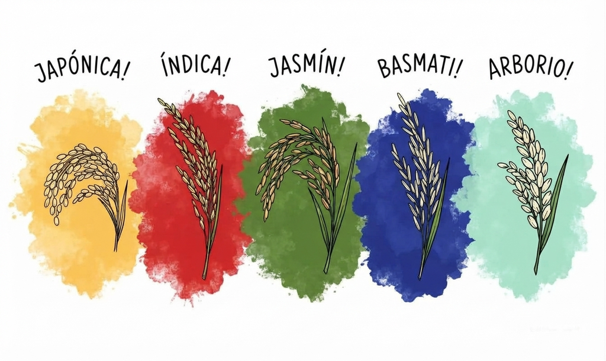

Ilustración de las variedades de grano de arroz

## 2. Diseño experimental

### 2.1 Estructura del DBCA

| Elemento | Descripción |
| --- | --- |
| **Factor (Tratamiento)** | Variedad de arroz (`Rice`) |
| **Niveles del factor** | 5: Japonica, Indica, Jasmine, Basmati, Arborio |
| **Factor de bloqueo** | Finca (`Farm`) |
| **Niveles del bloque** | 15: 1,2,3,…,15 |
| **Unidad experimental** | Cada parcela sembrada con una variedad, dentro de cada finca |
| **Réplicas por tratamiento** | 1 por cada finca (diseño balanceado, sin repetición dentro de bloque) |
| **Variables respuesta** | `FW` (peso fresco, g), `DW` (peso seco, g), `MP` (porcentaje de humedad, %) |

Es un DBCA porque, además del factor principal de tratamiento (Variedad), se introduce un factor de control (Finca) para aislar la variación sistemática atribuible a las condiciones particulares de cada parcela (suelo, riego, exposición). De esta forma, la variación atribuible a la finca no se mezcla con el error experimental, aumentando la precisión del análisis de las variedades.

### 2.2 Variables respuesta

| Variable | Nombre | Qué mide |
| --- | --- | --- |
| `FW` | Fresh Weight | Peso fresco del grano/planta (g) |
| `DW` | Dry Weight | Peso seco del grano/planta (g) |
| `MP` | Moisture Percentage | Porcentaje de humedad (%) |

`FW` y `DW` están biológicamente ligadas (el peso seco es una fracción del peso fresco), por lo que se espera una correlación fuerte entre ambas — a diferencia de `MP`, que captura una dimensión distinta (proporción de agua) y podría comportarse de forma más independiente.

### 2.3 Modelo estadístico

Para el caso multivariado, el modelo del DBCA es:

$$\mathbf{Y}_{ij} = \boldsymbol{\mu} +
\boldsymbol{\tau}_i + \boldsymbol{\beta}_j +
\boldsymbol{\varepsilon}_{ij}$$
donde $\mathbf{Y}_{ij}$ es el vector de las 3 medidas (FW, DW, MP) de la variedad $i$ en la finca $j$, $\boldsymbol{\mu}$ es el vector de medias generales, $\boldsymbol{\tau}_i$ es el efecto (vectorial) de la variedad $i$, $\boldsymbol{\beta}_j$ es el efecto (vectorial) de la finca $j$, y $\boldsymbol{\varepsilon}_{ij}$ es el vector de errores aleatorios.

**Hipótesis (Tratamiento - Variedad):**
$$H_0: \boldsymbol{\tau}_1 = \dots =
\boldsymbol{\tau}_5 = \mathbf{0} \qquad H_1: \text{al menos un }
\boldsymbol{\tau}_i \neq \mathbf{0}$$

## 3. Paquetes y datos

```r
library(tidyverse)
library(heplots)
library(mvnormtest)
library(psych)
library(emmeans)
library(agricolae)
```

**Data a analizar**

| Farm | Rice | FW | DW | MP |
| --- | --- | --- | --- | --- |
| Finca_1 | Japonica | 35.896858 | 7.8744044 | 13.494682 |
| Finca_1 | Indica | 16.553764 | 3.8092300 | 6.285593 |
| Finca_1 | Jasmine | 24.831025 | 5.0895034 | 12.050834 |
| Finca_1 | Basmati | 49.165040 | 10.4674424 | 1.050840 |
| Finca_1 | Arborio | 26.755177 | 6.2829519 | 12.858853 |
| Finca_2 | Japonica | 30.966820 | 4.5501679 | 13.040877 |
| Finca_2 | Indica | 10.640550 | 2.1029971 | 10.177639 |
| Finca_2 | Jasmine | 19.407165 | 2.3766478 | 17.607188 |
| Finca_2 | Basmati | 40.401811 | 7.4349475 | 7.047043 |
| Finca_2 | Arborio | 30.403887 | 4.5131226 | 8.096750 |

[output cut: 65 more lines]

## 4. Verificación de supuestos

### 4.1 Normalidad multivariada por grupo

```r
variedades <- unique(datos_arroz$Rice)
trat <- map(variedades, ~ datos_arroz %>% filter(Rice == .x) %>% dplyr::select(FW, DW, MP))
names(trat) <- variedades

map(trat, ~ mshapiro.test(t(as.matrix(.x))))
```

```
## $Japonica
##
##  Shapiro-Wilk normality test
##
## data:  Z
## W = 0.95273, p-value = 0.5684
##
##
## $Indica
##
##  Shapiro-Wilk normality test
##
## data:  Z
## W = 0.85314, p-value = 0.01924
##
##
## $Jasmine
##
##  Shapiro-Wilk normality test
##
## data:  Z
## W = 0.91217, p-value = 0.1462
##
##
## $Basmati
##
##  Shapiro-Wilk normality test
##
## data:  Z
## W = 0.92124, p-value = 0.2012
##
##
## $Arborio
##
##  Shapiro-Wilk normality test
##
## data:  Z
## W = 0.88721, p-value = 0.06086
```

### 4.2 Normalidad multivariada general

$$H_0: \text{Los residuales siguen una
distribución normal multivariada}$$
$$H_1: \text{Los residuales no siguen una
distribución normal multivariada}$$

```r
modelo_prelim <- manova(cbind(FW, DW, MP) ~ Farm + Rice, data = datos_arroz)
residuales <- residuals(modelo_prelim)

mshapiro.test(t(residuales))
```

```
##
##  Shapiro-Wilk normality test
##
## data:  Z
## W = 0.98206, p-value = 0.3674
```

### 4.3 Homogeneidad de matrices de covarianza (Box’s M)

```r
heplots::boxM(cbind(FW, DW, MP) ~ Rice, data = datos_arroz)
```

```
##
##  Box's M-test for Homogeneity of Covariance Matrices
##
## data:  datos_arroz
## Chi-Sq (approx.) = 13.8038, df = 24, p-value = 0.951
```

**Hipótesis a contrastar:**

$$H_0: \boldsymbol{\Sigma}_1 =
\boldsymbol{\Sigma}_2 = \boldsymbol{\Sigma}_3 = \boldsymbol{\Sigma}_4 =
\boldsymbol{\Sigma}_5$$
$$H_1:
\text{al menos una matriz de covarianza } \boldsymbol{\Sigma}_i \text{
es distinta}$$

**Interpretación:** p-valor = 0.951. No se rechaza H0: Las matrices de covarianza son homogéneas (no hay diferencia significativa entre ellas).

### 4.4 Prueba de esfericidad de Bartlett

Se requiere que las variables respuesta estén correlacionadas para justificar el uso de un análisis conjunto (MANOVA).

**Hipótesis a contrastar:**

$$H_0: \mathbf{R} = \mathbf{I} \quad
\text{(las variables respuesta no están correlacionadas)}$$
$$H_1: \mathbf{R} \neq \mathbf{I} \quad \text{(al
menos dos variables están correlacionadas)}$$

```r
cor(datos_arroz[, c("FW", "DW", "MP")])
```

```
##            FW         DW         MP
## FW  1.0000000  0.9085892 -0.2000785
## DW  0.9085892  1.0000000 -0.2726207
## MP -0.2000785 -0.2726207  1.0000000
```

```r
cortest.bartlett(cor(datos_arroz[, c("FW", "DW", "MP")]), n = nrow(datos_arroz))
```

```
## $chisq
## [1] 132.5989
##
## $p.value
## [1] 1.48924e-28
##
## $df
## [1] 3
```

**Interpretación:** `FW` y `DW` están fuertemente correlacionadas (r ≈ 0.91), como era de esperarse dado que el peso seco es una fracción del peso fresco. `MP` correlaciona débilmente con ambas. El p-valor de la prueba de Bartlett es prácticamente cero, por lo que **se rechaza H0**: las variables respuesta sí están correlacionadas en conjunto, lo que respalda usar un MANOVA en vez de tres ANOVAs univariados independientes.

## 5. Modelo MANOVA

```r
modelo <- manova(cbind(FW, DW, MP) ~ Farm + Rice, data = datos_arroz)

Matrices <- summary(modelo)$SS
B_Finca   <- Matrices$Farm
T_Variedad <- Matrices$Rice
W <- Matrices$Residuals

Total <- B_Finca + T_Variedad + W

eta2 <- 1 - det(W) / det(Total)
eta2
```

```
## [1] 0.9949897
```

### 5.1 Pruebas de hipótesis del modelo

**Para el factor Tratamiento (Variedad):**

$$H_0: \boldsymbol{\mu}_{\text{Japonica}}
= \boldsymbol{\mu}_{\text{Indica}} = \boldsymbol{\mu}_{\text{Jasmine}} =
\boldsymbol{\mu}_{\text{Basmati}} =
\boldsymbol{\mu}_{\text{Arborio}}$$
$$H_1: \text{Al menos un vector de promedios }
\boldsymbol{\mu}_i \text{ es diferente}$$

**Para el factor de Bloqueo (Finca):**

```r
summary(modelo, test = "Pillai")
```

```
##           Df Pillai approx F num Df den Df    Pr(>F)
## Farm      14 1.1889   2.6258     42    168 6.937e-06 ***
## Rice       4 1.7352  19.2080     12    168 < 2.2e-16 ***
## Residuals 56
## ---
## Signif. codes:  0 '***' 0.001 '**' 0.01 '*' 0.05 '.' 0.1 ' ' 1
```

```r
summary(modelo, test = "Wilks")
```

```
##           Df    Wilks approx F num Df den Df    Pr(>F)
## Farm      14 0.161414    3.255     42 160.96 4.703e-08 ***
## Rice       4 0.018999   41.431     12 143.16 < 2.2e-16 ***
## Residuals 56
## ---
## Signif. codes:  0 '***' 0.001 '**' 0.01 '*' 0.05 '.' 0.1 ' ' 1
```

```r
summary(modelo, test = "Hotelling-Lawley")
```

```
##           Df Hotelling-Lawley approx F num Df den Df    Pr(>F)
## Farm      14           3.2348    4.056     42    158  8.84e-11 ***
## Rice       4          12.5952   55.279     12    158 < 2.2e-16 ***
## Residuals 56
## ---
## Signif. codes:  0 '***' 0.001 '**' 0.01 '*' 0.05 '.' 0.1 ' ' 1
```

```r
summary(modelo, test = "Roy")
```

```
##           Df    Roy approx F num Df den Df    Pr(>F)
## Farm      14 2.5903   10.361     14     56 5.888e-11 ***
## Rice       4 7.4679  104.550      4     56 < 2.2e-16 ***
## Residuals 56
## ---
## Signif. codes:  0 '***' 0.001 '**' 0.01 '*' 0.05 '.' 0.1 ' ' 1
```

```r
# Para cada variable respuesta individual (ANOVAs univariados)
summary.aov(modelo)
```

```
##  Response FW :
##             Df Sum Sq Mean Sq  F value Pr(>F)
## Farm        14  159.2   11.37   0.7005 0.7643
## Rice         4 6547.9 1636.96 100.8357 <2e-16 ***
## Residuals   56  909.1   16.23
## ---
## Signif. codes:  0 '***' 0.001 '**' 0.01 '*' 0.05 '.' 0.1 ' ' 1
##
##  Response DW :
##             Df  Sum Sq Mean Sq F value    Pr(>F)
## Farm        14  46.374   3.312  4.0121  9.43e-05 ***
## Rice         4 234.897  58.724 71.1276 < 2.2e-16 ***
## Residuals   56  46.235   0.826
## ---
## Signif. codes:  0 '***' 0.001 '**' 0.01 '*' 0.05 '.' 0.1 ' ' 1
##
##  Response MP :
##             Df  Sum Sq Mean Sq F value  Pr(>F)
## Farm        14   98.63   7.045  1.9111 0.04473 *
## Rice         4 1100.25 275.062 74.6150 < 2e-16 ***
## Residuals   56  206.44   3.686
## ---
## Signif. codes:  0 '***' 0.001 '**' 0.01 '*' 0.05 '.' 0.1 ' ' 1
```

**Interpretación**: El efecto de `Rice` (variedad) es altamente significativo con la prueba de Wilks ($\Lambda \approx 0.019$, p < 0.001); el efecto de Farm (finca) también lo es ($\Lambda \approx 0.161$, p < 0.001), indicando que ambos factores explican una gran proporción de la variabilidad conjunta. Los ANOVAs univariados muestran que la variedad genera diferencias contundentes en todas las variables respuesta (FW, DW y MP, todas con p < 0.001). Por su parte, las diferencias entre fincas provienen principalmente de DW (p < 0.001) y, en menor medida, de MP (p ≈ 0.045); FW por sí sola no alcanza significancia entre fincas (p ≈ 0.764), aunque sí se ve afectada globalmente por la variedad.

## 6. Pruebas de comparación

### 6.1 Comparación General por pares (Ajuste de Holm)

```r
fit <- lm(cbind(FW, DW, MP) ~ Farm + Rice, data = datos_arroz)
emm <- emmeans(fit, ~ Rice | rep.meas)

mvcontrast(emm, method = "pairwise", mult.name = "rep.meas", adjust = "holm")
```

|  | contrast | T.square | df1 | df2 | F.ratio | p.value |
| --- | --- | --- | --- | --- | --- | --- |
| 1 | Arborio - Basmati | 86.23230 | 3 | 54 | 27.71753 | 1.100370e-10 |
| 4 | Arborio - Indica | 124.34722 | 3 | 54 | 39.96875 | 4.807312e-13 |
| 7 | Arborio - Japonica | 68.61315 | 3 | 54 | 22.05423 | 1.868825e-09 |
| 10 | Arborio - Jasmine | 88.62101 | 3 | 54 | 28.48533 | 1.058084e-10 |
| 13 | Basmati - Indica | 319.11266 | 3 | 54 | 102.57193 | 2.473398e-21 |
| 16 | Basmati - Japonica | 194.68284 | 3 | 54 | 62.57663 | 9.799896e-17 |
| 19 | Basmati - Jasmine | 344.73261 | 3 | 54 | 110.80691 | 4.641559e-22 |
| 22 | Indica - Japonica | 315.60012 | 3 | 54 | 101.44289 | 2.832140e-21 |
| 25 | Indica - Jasmine | 129.64911 | 3 | 54 | 41.67293 | 2.654403e-13 |
| 28 | Japonica - Jasmine | 91.73050 | 3 | 54 | 29.48480 | 7.993199e-11 |

### 6.2 Comparaciones univariadas con ajuste de Tukey

```r
modelo_MP <- aov(MP ~ Farm + Rice, data = datos_arroz)
modelo_DW <- aov(DW ~ Farm + Rice, data = datos_arroz)

emmeans(modelo_MP, pairwise ~ Rice, adjust = "tukey")
```

```
## $emmeans
##  Rice     emmean    SE df lower.CL upper.CL
##  Arborio    9.17 0.496 56     8.17    10.16
##  Basmati    4.25 0.496 56     3.26     5.24
##  Indica     7.90 0.496 56     6.91     8.90
##  Japonica  13.83 0.496 56    12.83    14.82
##  Jasmine   14.54 0.496 56    13.54    15.53
##
## Results are averaged over the levels of: Farm
## Confidence level used: 0.95
##
## $contrasts
##  contrast           estimate    SE df t.ratio p.value
##  Arborio - Basmati     4.917 0.701 56   7.013 <0.0001
##  Arborio - Indica      1.265 0.701 56   1.804  0.3818
##  Arborio - Japonica   -4.660 0.701 56  -6.646 <0.0001
##  Arborio - Jasmine    -5.369 0.701 56  -7.658 <0.0001
##  Basmati - Indica     -3.652 0.701 56  -5.209 <0.0001
##  Basmati - Japonica   -9.576 0.701 56 -13.659 <0.0001
##  Basmati - Jasmine   -10.285 0.701 56 -14.671 <0.0001
##  Indica - Japonica    -5.924 0.701 56  -8.450 <0.0001
##  Indica - Jasmine     -6.633 0.701 56  -9.462 <0.0001
##  Japonica - Jasmine   -0.709 0.701 56  -1.011  0.8491
##
## Results are averaged over the levels of: Farm
## P value adjustment: tukey method for comparing a family of 5 estimates
```

```r
emmeans(modelo_DW, pairwise ~ Rice, adjust = "tukey")
```

```
## $emmeans
##  Rice     emmean    SE df lower.CL upper.CL
##  Arborio    5.84 0.235 56     5.37     6.31
##  Basmati    7.73 0.235 56     7.26     8.20
##  Indica     2.86 0.235 56     2.39     3.33
##  Japonica   6.51 0.235 56     6.04     6.98
##  Jasmine    3.86 0.235 56     3.39     4.33
##
## Results are averaged over the levels of: Farm
## Confidence level used: 0.95
##
## $contrasts
##  contrast           estimate    SE df t.ratio p.value
##  Arborio - Basmati    -1.898 0.332 56  -5.721 <0.0001
##  Arborio - Indica      2.972 0.332 56   8.958 <0.0001
##  Arborio - Japonica   -0.674 0.332 56  -2.032  0.2647
##  Arborio - Jasmine     1.974 0.332 56   5.950 <0.0001
##  Basmati - Indica      4.870 0.332 56  14.678 <0.0001
##  Basmati - Japonica    1.224 0.332 56   3.689  0.0045
##  Basmati - Jasmine     3.872 0.332 56  11.670 <0.0001
##  Indica - Japonica    -3.646 0.332 56 -10.990 <0.0001
##  Indica - Jasmine     -0.998 0.332 56  -3.008  0.0309
##  Japonica - Jasmine    2.648 0.332 56   7.981 <0.0001
##
## Results are averaged over the levels of: Farm
## P value adjustment: tukey method for comparing a family of 5 estimates
```

-Para MP: Las variedades Jasmine ($\approx 14.54$) y Japonica ($\approx 13.83$) presentan los valores más altos y no difieren significativamente entre sí ($p = 0.849$). De manera similar, Arborio ($\approx 9.17$) e Indica ($\approx 7.90$) forman un grupo intermedio sin diferencias estadísticas ($p = 0.382$). Por último, Basmati presenta el valor significativamente más bajo ($\approx 4.25$, $p < 0.001$).

-Para DW: Basmati alcanza el mayor peso seco promedio ($\approx 7.73$), superando a todas las demás variedades ($p \le 0.004$). Le siguen Japonica ($\approx 6.51$) y Arborio ($\approx 5.84$), las cuales no presentan diferencias significativas entre sí ($p = 0.265$). En el extremo inferior, Jasmine ($\approx 3.86$) e Indica ($\approx 2.86$) muestran los menores rendimientos, diferenciándose significativamente entre ellas ($p = 0.031$).

## 7. Conclusiones y Discusiones

### 7.1 Discusión

Por otro lado, la prueba de esfericidad de Bartlett confirmó una fuerte correlación positiva entre FW y DW, validando de manera empírica el uso de un análisis multivariado conjunto en lugar de abordajes univariados independientes. Además, al contar con un diseño balanceado de 15 réplicas por variedad (75 observaciones en total), el modelo tuvo suficiente robustez para evaluar y cumplir adecuadamente los supuestos críticos de normalidad en los residuales y homogeneidad de matrices de covarianza (Box’s M), asegurando la fiabilidad de las inferencias.

### 7.2 Conclusiones

1. **Efecto de la Variedad:** Se rechaza contundentemente la hipótesis nula global (Wilks, $p < 0.001$). La variedad genética tiene un impacto determinante sobre todas las características evaluadas (peso fresco, peso seco y humedad) del grano de arroz.
2. **Efecto del Bloqueo (Finca):** Se comprobó la eficacia e importancia del bloqueo (Wilks, $p < 0.001$). Las condiciones particulares de cada finca introducen una variabilidad significativa en el cultivo, alterando el rendimiento del peso seco y la retención de humedad, aunque sin tener un impacto directo sobre el peso fresco.
3. **Diferenciación:** La variedad Basmati se distingue del resto por alcanzar el mayor rendimiento en peso seco al mismo tiempo que mantiene el porcentaje de humedad significativamente más bajo. En contraste, Jasmine y Japonica retienen la mayor cantidad de humedad, mientras que Indica y la propia Jasmine reportan los pesos secos más bajos.
4. **Idoneidad del Diseño:** El cumplimiento de la homogeneidad de covarianzas multivariadas ($p = 0.951$) y la alta proporción de varianza explicada consolidan al MANOVA con estructura de DBCA como una herramienta analítica precisa para evaluar este conjunto de datos sin necesidad de recurrir a alternativas no paramétricas.

# Pregunta 7 — MANOVA con experimento factorial en un DCA

**Base de datos:** `Drones.xlsx` — tiempo de vuelo y capacidad de carga de drones según material de batería y clima.

## Descripción del caso

Se hizo un estudio con dos tipos de material de batería y dos condiciones de clima, y con cada tratamiento (combinación de material y clima) se registraron 15 repeticiones del tiempo de vuelo (minutos) y la capacidad de carga retenida (mAh) en drones de prueba.

**Factores:**

- **Material**: Litio / Grafeno
- **Clima** : Frío / Calor

**Variables respuesta:**

- **Vuelo**: Tiempo de vuelo (minutos)
- **Carga**: Capacidad de carga retenida (mAh)

Se utilizó un Diseño Completamente al Azar (DCA) con arreglo factorial 2x2, 15 repeticiones por cada combinación de tratamiento (60 observaciones en total).

## Pregunta: Manova con Análisis Factorial en DCA

> ¿Afectan el material de la batería, la condición climática y la interacción entre ambos factores al desempeño conjunto de los drones, medido a través del tiempo de vuelo y la capacidad de carga retenida?

### Introducción

El Análisis de Variancia Multivariado (MANOVA) permite evaluar simultáneamente el efecto de uno o más factores sobre varias variables respuesta que están correlacionadas entre sí, en lugar de analizarlas por separado mediante ANOVAs univariados independientes. Esto es relevante en el presente caso, ya que el tiempo de vuelo y la capacidad de carga retenida de un dron no son variables independientes: ambas dependen del comportamiento de la batería bajo distintas condiciones de material y clima.

El objetivo de este análisis es determinar si el tipo de material de la batería (Litio o Grafeno), la condición climática (Frío o Calor), y la interacción entre ambos factores, tienen un efecto estadísticamente significativo sobre el vector de medias conformado por el tiempo de vuelo y la capacidad de carga retenida, bajo un diseño completamente al azar con arreglo factorial 2x2.

### Modelo estadístico

#### Modelo aditivo lineal

Para el caso multivariado, el modelo aditivo lineal de un experimento factorial de dos factores en un DCA es:

$$\mathbf{Y}_{ijk} = \boldsymbol{\mu} +
\boldsymbol{\alpha}_i + \boldsymbol{\beta}_j +
(\boldsymbol{\alpha\beta})_{ij} + \boldsymbol{\varepsilon}_{ijk}, \qquad
i = 1,2; \ j = 1,2; \ k = 1,\dots,15$$

donde:

- $\mathbf{Y}_{ijk} = (\text{Vuelo}_{ijk}, \text{Carga}_{ijk})'$: es el vector de las 2 variables respuesta del dron $k$ con el material $i$ expuesto al clima $j$.
- $\boldsymbol{\mu}$: es el vector de medias generales.
- $\boldsymbol{\alpha}_i$: es el efecto del $i$-ésimo nivel de Material.
- $\boldsymbol{\beta}_j$: es el efecto del $j$-ésimo nivel de Clima.
- $(\boldsymbol{\alpha\beta})_{ij}$: es el efecto de la interacción Material×Clima.
- $\boldsymbol{\varepsilon}_{ijk} \overset{iid}{\sim} N_2(\mathbf{0},\boldsymbol{\Sigma})$: es el vector de errores aleatorios.

Con las restricciones: $\sum_i \boldsymbol{\alpha}_i = \mathbf{0}$, $\sum_j \boldsymbol{\beta}_j = \mathbf{0}$ y $\sum_i (\boldsymbol{\alpha\beta})_{ij} = \sum_j (\boldsymbol{\alpha\beta})_{ij} = \mathbf{0}$.

#### Hipótesis a contrastar

**Interacción Material × Clima** (se contrasta primero):

$$H_0: (\boldsymbol{\alpha\beta})_{ij} =
\mathbf{0} \ \text{ para todo } i,j \qquad H_1: \text{al menos un }
(\boldsymbol{\alpha\beta})_{ij} \neq \mathbf{0}$$

**Efecto principal de Material:**

$$H_0: \boldsymbol{\alpha}_{\text{Litio}}
= \boldsymbol{\alpha}_{\text{Grafeno}} = \mathbf{0} \qquad H_1: \text{al
menos un } \boldsymbol{\alpha}_i \neq \mathbf{0}$$

**Efecto principal de Clima:**

$$H_0: \boldsymbol{\beta}_{\text{Frío}} =
\boldsymbol{\beta}_{\text{Calor}} = \mathbf{0} \qquad H_1: \text{al
menos un } \boldsymbol{\beta}_j \neq \mathbf{0}$$

#### Supuestos del modelo

1. **Independencia** de las observaciones (garantizada por la aleatorización del DCA).
2. **Normalidad multivariada** de los errores en cada tratamiento.
3. **Homogeneidad de las matrices de varianza-covarianza** entre los 4 tratamientos.
4. **Correlación entre las variables respuesta** (condición que justifica el uso de MANOVA).

### Desarrollo

#### Supuesto de independencia

Al ser un DCA, los tratamientos se asignaron completamente al azar a los drones de prueba y cada dron aporta una única observación (un vector de 2 medidas), por lo que las observaciones se consideran independientes. Además, el diseño es balanceado (15 repeticiones por tratamiento):

```r
table(Material = datos$Material, Clima = datos$Clima)
```

```
##          Clima
## Material  Calor Frio
##   Grafeno    15   15
##   Litio      15   15
```

#### Supuesto de normalidad multivariada

Desagregamos la base por grupos (combinaciones de Material y Clima) y aplicamos el test de Shapiro multivariado (Royston) a cada uno.

**Hipótesis a contrastar:**

$$H_0: \text{Los datos siguen una
distribución normal multivariada}$$
$$H_1: \text{Los datos no siguen una distribución
normal multivariada}$$

Tratamiento 1 (Litio - Frío)

```r
sw1 <- mvnormtest::mshapiro.test(t(trat1))
sw1
```

```
##
##  Shapiro-Wilk normality test
##
## data:  Z
## W = 0.30443, p-value = 1.334e-07
```

Tratamiento 2 (Grafeno - Frío)

```r
sw2 <- mvnormtest::mshapiro.test(t(trat2))
sw2
```

```
##
##  Shapiro-Wilk normality test
##
## data:  Z
## W = 0.28614, p-value = 1.013e-07
```

Tratamiento 3 (Litio - Calor)

```r
sw3 <- mvnormtest::mshapiro.test(t(trat3))
sw3
```

```
##
##  Shapiro-Wilk normality test
##
## data:  Z
## W = 0.28782, p-value = 1.039e-07
```

Tratamiento 4 (Grafeno - Calor)

```r
sw4 <- mvnormtest::mshapiro.test(t(trat4))
sw4
```

```
##
##  Shapiro-Wilk normality test
##
## data:  Z
## W = 0.28492, p-value = 9.949e-08
```

> **Interpretación:** En los cuatro tratamientos el p-valor es menor a 0.05 (el mayor es 1.33^{-7}), por lo que se rechaza $H_0$: no hay normalidad multivariada en ninguno de los tratamientos. Por ello se decide utilizar las pruebas más robustas descritas en el curso.

#### Supuesto de homogeneidad de matrices varianza-covarianza

**Hipótesis a contrastar:**

$$H_0:
\boldsymbol{\Sigma}_{\text{Litio-Frío}} =
\boldsymbol{\Sigma}_{\text{Grafeno-Frío}} =
\boldsymbol{\Sigma}_{\text{Litio-Calor}} =
\boldsymbol{\Sigma}_{\text{Grafeno-Calor}}$$
$$H_1: \text{al menos una matriz de covarianza }
\boldsymbol{\Sigma}_i \text{ es distinta}$$

```r
bm <- heplots::boxM(cbind(Vuelo, Carga) ~ Material * Clima, data = datos)
bm
```

```
##
##  Box's M-test for Homogeneity of Covariance Matrices
##
## data:  datos
## Chi-Sq (approx.) = 323.7236, df = 9, p-value = < 2.2e-16
```

> **Interpretación:** El p-valor de la prueba de Box’s M es 2.4^{-64}, menor a 0.05, por lo que se rechaza $H_0$. No existe homogeneidad de matrices varianza-covarianza, lo que nos confirma que debemos utilizar las pruebas más robustas.

#### Supuesto de variables dependientes correlacionadas: Prueba de esfericidad de Bartlett

**Hipótesis a contrastar:**

$$H_0: \mathbf{R} = \mathbf{I} \quad
\text{(las variables respuesta no están correlacionadas)}$$
$$H_1: \mathbf{R} \neq \mathbf{I} \quad \text{(las
variables respuesta están correlacionadas)}$$

```r
datos1 <- datos %>% dplyr::select(Vuelo, Carga)
cor(datos1)
```

```
##           Vuelo     Carga
## Vuelo 1.0000000 0.9944571
## Carga 0.9944571 1.0000000
```

```r
bart <- cortest.bartlett(cor(datos1), n = nrow(datos1))
bart
```

```
## $chisq
## [1] 259.0301
##
## $p.value
## [1] 2.792152e-58
##
## $df
## [1] 1
```

> **Interpretación:** La correlación entre Vuelo y Carga es 0.994 y el p-valor de la prueba es 2.79^{-58}, menor a 0.05, por lo que se rechaza $H_0$. Las variables están correlacionadas, por lo que es adecuado utilizar un MANOVA en lugar de ANOVAs univariados independientes.

#### Matriz residual y matrices factoriales del MANOVA

Variabilidad explicada por el factor Material (SCOCFMaterial):

```r
FMaterial
```

```
##            Vuelo     Carga
## Vuelo   509313.1  13884493
## Carga 13884493.3 378508167
```

Variabilidad explicada por el factor Clima (SCOCFClima):

```r
FClima
```

```
##           Vuelo    Carga
## Vuelo  160994.4  3900540
## Carga 3900540.0 94501500
```

Variabilidad explicada por la interacción Material*Clima (SCOCFMaterial*Clima):

```r
FMaterialClima
```

```
##            Vuelo    Carga
## Vuelo   91416.07  1760403
## Carga 1760403.33 33900167
```

Variabilidad residual (SCOCR):

```r
W
```

```
##           Vuelo      Carga
## Vuelo  3173.118   58930.61
## Carga 58930.613 1168610.67
```

Variabilidad total (SCOCT):

```r
T_mat <- FMaterial + FClima + FMaterialClima + W
T_mat
```

```
##            Vuelo     Carga
## Vuelo   764896.7  19604367
## Carga 19604367.3 508078444
```

##### Bondad de ajuste

$$\eta^2 = 1 -
\frac{|\mathbf{W}|}{|\mathbf{T}|}$$

```r
eta2 <- 1 - det(W) / det(T_mat)
eta2
```

```
## [1] 0.9999452
```

> **Interpretación:** El valor de $\eta^2$ es 0.9999, es decir, el 99.99% de la variabilidad total conjunta puede atribuirse al factorial (Material, Clima e interacción). Como es cercano a 1, el uso de un diseño experimental factorial en DCA es adecuado.

#### Pruebas de hipótesis del modelo

Se contrastan las hipótesis planteadas para la interacción y los efectos principales de Material y Clima. Dado el incumplimiento de los supuestos de normalidad y homogeneidad de matrices, se prioriza el criterio de Pillai, aunque se calculan los cuatro criterios.

Criterio de Pillai

```r
pillai <- summary(modelo, test = "Pillai")
pillai
```

```
##                Df  Pillai approx F num Df den Df    Pr(>F)
## Material        1 0.99853  18673.9      2     55 < 2.2e-16 ***
## Clima           1 0.99175   3305.0      2     55 < 2.2e-16 ***
## Material:Clima  1 0.96709    808.2      2     55 < 2.2e-16 ***
## Residuals      56
## ---
## Signif. codes:  0 '***' 0.001 '**' 0.01 '*' 0.05 '.' 0.1 ' ' 1
```

Criterio de Lambda de Wilk´s

```r
summary(modelo, test = "Wilks")
```

```
##                Df    Wilks approx F num Df den Df    Pr(>F)
## Material        1 0.001470  18673.9      2     55 < 2.2e-16 ***
## Clima           1 0.008252   3305.0      2     55 < 2.2e-16 ***
## Material:Clima  1 0.032907    808.2      2     55 < 2.2e-16 ***
## Residuals      56
## ---
## Signif. codes:  0 '***' 0.001 '**' 0.01 '*' 0.05 '.' 0.1 ' ' 1
```

Criterio de Lawley y Hotelling

```r
summary(modelo, test = "Hotelling-Lawley")
```

```
##                Df Hotelling-Lawley approx F num Df den Df    Pr(>F)
## Material        1           679.05  18673.9      2     55 < 2.2e-16 ***
## Clima           1           120.18   3305.0      2     55 < 2.2e-16 ***
## Material:Clima  1            29.39    808.2      2     55 < 2.2e-16 ***
## Residuals      56
## ---
## Signif. codes:  0 '***' 0.001 '**' 0.01 '*' 0.05 '.' 0.1 ' ' 1
```

Criterio de Roy´s

```r
summary(modelo, test = "Roy")
```

```
##                Df    Roy approx F num Df den Df    Pr(>F)
## Material        1 679.05  18673.9      2     55 < 2.2e-16 ***
## Clima           1 120.18   3305.0      2     55 < 2.2e-16 ***
## Material:Clima  1  29.39    808.2      2     55 < 2.2e-16 ***
## Residuals      56
## ---
## Signif. codes:  0 '***' 0.001 '**' 0.01 '*' 0.05 '.' 0.1 ' ' 1
```

ANOVAs univariados para cada variable respuesta

```r
summary.aov(modelo)
```

```
##  Response Vuelo :
##                Df Sum Sq Mean Sq F value    Pr(>F)
## Material        1 509313  509313  8988.5 < 2.2e-16 ***
## Clima           1 160994  160994  2841.3 < 2.2e-16 ***
## Material:Clima  1  91416   91416  1613.3 < 2.2e-16 ***
## Residuals      56   3173      57
## ---
## Signif. codes:  0 '***' 0.001 '**' 0.01 '*' 0.05 '.' 0.1 ' ' 1
##
##  Response Carga :
##                Df    Sum Sq   Mean Sq F value    Pr(>F)
## Material        1 378508167 378508167 18138.2 < 2.2e-16 ***
## Clima           1  94501500  94501500  4528.5 < 2.2e-16 ***
## Material:Clima  1  33900167  33900167  1624.5 < 2.2e-16 ***
## Residuals      56   1168611     20868
## ---
## Signif. codes:  0 '***' 0.001 '**' 0.01 '*' 0.05 '.' 0.1 ' ' 1
```

> **Interpretación:** Con el criterio de Pillai, la interacción Material*Clima es significativa (p = 1.68^{-41}), al igual que los efectos principales de Material (p = 1.27^{-78}) y Clima (p = 5.07^{-58}); se rechaza $H_0$ en los tres casos y los cuatro criterios coinciden. Los ANOVAs univariados muestran que los efectos también son significativos en Vuelo y en Carga por separado. Como la interacción es significativa, los efectos principales no deben interpretarse de forma aislada, por lo que se procede con el análisis de efectos simples.

#### Análisis de efectos simples

Dado que resulta que la interacción Material*Clima es significativa, se realiza el análisis de efectos simples, es decir, se contrasta el efecto de un factor dentro de cada nivel del otro:

$$H_0: \boldsymbol{\alpha}_{\text{Litio}}
= \boldsymbol{\alpha}_{\text{Grafeno}} \ \text{(dentro de cada Clima)}
\qquad H_0: \boldsymbol{\beta}_{\text{Frío}} =
\boldsymbol{\beta}_{\text{Calor}} \ \text{(dentro de cada
Material)}$$

##### Efectos simples de Material dentro de cada nivel de Clima

```r
levels(datos$Clima) %>% lapply(function(nivel_Clima) {
  cat("\n--- Análisis para Clima =", nivel_Clima, "---\n")
  subdatos <- filter(datos, Clima == nivel_Clima)
  summary(manova(cbind(Vuelo, Carga) ~ Material, data = subdatos), test = "Pillai")
})
```

```
##
## --- Análisis para Clima = Calor ---
##
## --- Análisis para Clima = Frio ---
```

```
## [[1]]
##           Df Pillai approx F num Df den Df    Pr(>F)
## Material   1 0.9994    22647      2     27 < 2.2e-16 ***
## Residuals 28
## ---
## Signif. codes:  0 '***' 0.001 '**' 0.01 '*' 0.05 '.' 0.1 ' ' 1
##
## [[2]]
##           Df  Pillai approx F num Df den Df    Pr(>F)
## Material   1 0.99786   6296.5      2     27 < 2.2e-16 ***
## Residuals 28
## ---
## Signif. codes:  0 '***' 0.001 '**' 0.01 '*' 0.05 '.' 0.1 ' ' 1
```

##### Efectos simples de Clima dentro de cada nivel de Material

```r
levels(datos$Material) %>% lapply(function(nivel_Material) {
  cat("\n--- Análisis para Material =", nivel_Material, "---\n")
  subdatos <- filter(datos, Material == nivel_Material)
  summary(manova(cbind(Vuelo, Carga) ~ Clima, data = subdatos), test = "Pillai")
})
```

```
##
## --- Análisis para Material = Grafeno ---
##
## --- Análisis para Material = Litio ---
```

```
## [[1]]
##           Df  Pillai approx F num Df den Df    Pr(>F)
## Clima      1 0.99601   3366.8      2     27 < 2.2e-16 ***
## Residuals 28
## ---
## Signif. codes:  0 '***' 0.001 '**' 0.01 '*' 0.05 '.' 0.1 ' ' 1
##
## [[2]]
##           Df  Pillai approx F num Df den Df    Pr(>F)
## Clima      1 0.98513   894.12      2     27 < 2.2e-16 ***
## Residuals 28
## ---
## Signif. codes:  0 '***' 0.001 '**' 0.01 '*' 0.05 '.' 0.1 ' ' 1
```

#### Visualización de los efectos

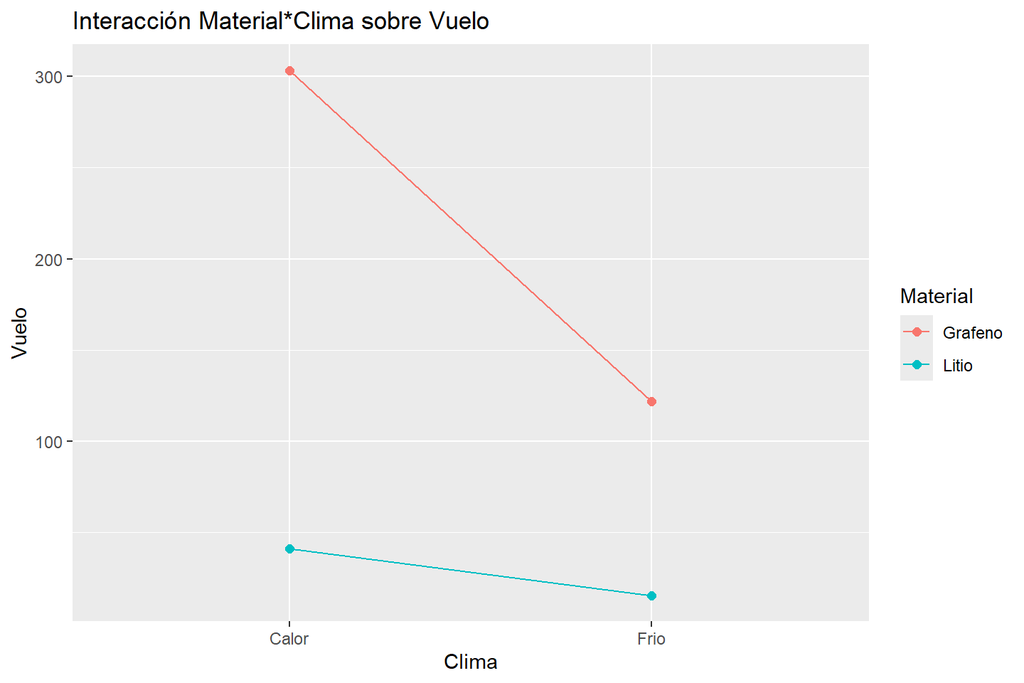

```r
ggplot(promedios, aes(x = Clima, y = Vuelo, group = Material, color = Material)) +
  geom_line() + geom_point(size = 2) +
  labs(title = "Interacción Material*Clima sobre Vuelo")
```

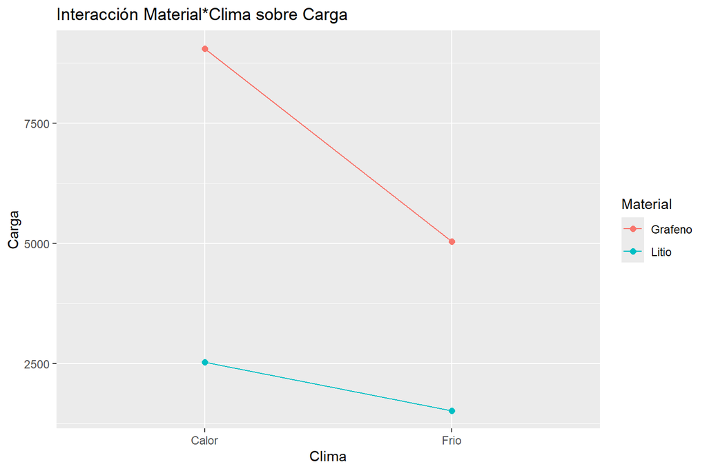

```r
ggplot(promedios, aes(x = Clima, y = Carga, group = Material, color = Material)) +
  geom_line() + geom_point(size = 2) +
  labs(title = "Interacción Material*Clima sobre Carga")
```

> **Interpretación:** Las líneas no son paralelas en ninguno de los dos gráficos: la ventaja del Grafeno sobre el Litio y el aumento al pasar de Frío a Calor son mucho mayores en unas condiciones que en otras, lo que evidencia visualmente la interacción.

#### Tabla de efectos simples (p-valores)

```r
efecto_Material_en_Clima <- list()
efecto_Clima_en_Material <- list()

for (nivel_Clima in levels(datos$Clima)) {
  subdatos <- filter(datos, Clima == nivel_Clima)
  manova_mod <- manova(cbind(Vuelo, Carga) ~ Material, data = subdatos)
  pval <- summary(manova_mod, test = "Pillai")$stats["Material", "Pr(>F)"]
  efecto_Material_en_Clima[[nivel_Clima]] <- pval
}

for (nivel_Material in levels(datos$Material)) {
  subdatos <- filter(datos, Material == nivel_Material)
  manova_mod <- manova(cbind(Vuelo, Carga) ~ Clima, data = subdatos)
  pval <- summary(manova_mod, test = "Pillai")$stats["Clima", "Pr(>F)"]
  efecto_Clima_en_Material[[nivel_Material]] <- pval
}

tabla_efecto_Material_en_Clima <- tibble(
  `Nivel de Clima` = names(efecto_Material_en_Clima),
  `p-valor efecto de Material` = unlist(efecto_Material_en_Clima)
)

tabla_efecto_Clima_en_Material <- tibble(
  `Nivel de Material` = names(efecto_Clima_en_Material),
  `p-valor efecto de Clima` = unlist(efecto_Clima_en_Material)
)

print(tabla_efecto_Material_en_Clima)
```

```
## # A tibble: 2 × 2
##   `Nivel de Clima` `p-valor efecto de Material`
##   <chr>                                   <dbl>
## 1 Calor                                2.91e-44
## 2 Frio                                 9.10e-37
```

```r
print(tabla_efecto_Clima_en_Material)
```

```
## # A tibble: 2 × 2
##   `Nivel de Material` `p-valor efecto de Clima`
##   <chr>                                   <dbl>
## 1 Grafeno                              4.16e-33
## 2 Litio                                2.13e-25
```

> **Interpretación:** Todos los efectos simples son significativos (p < 0.05): el Material afecta el desempeño tanto en Frío como en Calor, y el Clima lo afecta tanto en Litio como en Grafeno.

#### Comparación general por pares con basada en la distribución de Hotelling

##### Efecto simple de Material dentro de cada nivel de Clima

```r
emmMaterial <- emmeans(fit, ~ Material | Clima | rep.meas)

mvcontrast(emmMaterial, method = 'pairwise', mult.name = 'rep.meas',
           by = 'Clima', adjust = 'holm')
```

|  | contrast | Clima | T.square | df1 | df2 | F.ratio | p.value |
| --- | --- | --- | --- | --- | --- | --- | --- |
| 1 | Grafeno - Litio | Calor | 24614.54 | 2 | 55 | 12087.498 | 1.950999e-73 |
| 3 | Grafeno - Litio | Frio | 15058.13 | 2 | 55 | 7394.617 | 1.387184e-67 |

```r
mvcontrast(emmMaterial, method = 'pairwise', mult.name = 'rep.meas',
           by = 'Clima', adjust = 'none')
```

|  | contrast | Clima | T.square | df1 | df2 | F.ratio | p.value |
| --- | --- | --- | --- | --- | --- | --- | --- |
| 1 | Grafeno - Litio | Calor | 24614.54 | 2 | 55 | 12087.498 | 1.950999e-73 |
| 3 | Grafeno - Litio | Frio | 15058.13 | 2 | 55 | 7394.617 | 1.387184e-67 |

##### Efecto simple de Clima dentro de cada nivel de Material

```r
emmClima <- emmeans(fit, ~ Clima | Material | rep.meas)

mvcontrast(emmClima, method = 'pairwise', mult.name = 'rep.meas',
           by = 'Material', adjust = 'bonferroni')
```

|  | contrast | Material | T.square | df1 | df2 | F.ratio | p.value |
| --- | --- | --- | --- | --- | --- | --- | --- |
| 1 | Calor - Frio | Grafeno | 6684.031 | 2 | 55 | 3282.337 | 6.123069e-58 |
| 3 | Calor - Frio | Litio | 1691.960 | 2 | 55 | 830.873 | 8.045594e-42 |

```r
mvcontrast(emmClima, method = 'pairwise', mult.name = 'rep.meas',
           by = 'Material', adjust = 'none')
```

|  | contrast | Material | T.square | df1 | df2 | F.ratio | p.value |
| --- | --- | --- | --- | --- | --- | --- | --- |
| 1 | Calor - Frio | Grafeno | 6684.031 | 2 | 55 | 3282.337 | 6.123069e-58 |
| 3 | Calor - Frio | Litio | 1691.960 | 2 | 55 | 830.873 | 8.045594e-42 |

##### Comparación de las cuatro combinaciones de tratamiento

Para identificar qué combinación ofrece el mejor desempeño, se comparan por pares las cuatro combinaciones de tratamiento:

```r
emmMatClima <- emmeans(fit, ~ Material * Clima | rep.meas)

mvcontrast(emmMatClima, method = 'pairwise', mult.name = 'rep.meas',
           adjust = 'bonferroni')
```

|  | contrast | T.square | df1 | df2 | F.ratio | p.value |
| --- | --- | --- | --- | --- | --- | --- |
| 1 | Grafeno Calor - Litio Calor | 24614.541 | 2 | 55 | 12087.498 | 1.170599e-72 |
| 3 | Grafeno Calor - Grafeno Frio | 6684.031 | 2 | 55 | 3282.337 | 3.673841e-57 |
| 5 | Grafeno Calor - Litio Frio | 38059.013 | 2 | 55 | 18689.694 | 7.467580e-78 |
| 7 | Litio Calor - Grafeno Frio | 6698.159 | 2 | 55 | 3289.275 | 3.468261e-57 |
| 9 | Litio Calor - Litio Frio | 1691.960 | 2 | 55 | 830.873 | 4.827356e-41 |
| 11 | Grafeno Frio - Litio Frio | 15058.130 | 2 | 55 | 7394.617 | 8.323102e-67 |

Promedios de cada combinación de tratamiento:

```r
promedios
```

| Material | Clima | Vuelo | Carga |
| --- | --- | --- | --- |
| Grafeno | Calor | 303.33333 | 9053.333 |
| Grafeno | Frio | 121.66667 | 5040.000 |
| Litio | Calor | 41.00000 | 2526.667 |
| Litio | Frio | 15.46667 | 1520.000 |

> **Interpretación:** Los seis pares de combinaciones difieren significativamente. La combinación Grafeno-Calor presenta los mayores promedios tanto en tiempo de vuelo como en capacidad de carga retenida.

### Discusión

- No se cumplieron los supuestos de normalidad multivariada (en ninguno de los tratamientos) ni de homogeneidad de matrices varianza-covarianza. Por esto, el estadístico multivariado más apropiado de reportar es el de Pillai, puesto que es robusto al incumplimiento de estos supuestos, y más aún al tratarse de un diseño balanceado (15 repeticiones por tratamiento). Su p-valor indica que la interacción tiene un efecto significativo sobre las variables respuesta. La prueba de Bartlett confirmó que las variables están correlacionadas, lo que justifica el MANOVA.
- Tras realizar las pruebas robustas resultó significativa la interacción Material*Clima. En el análisis de efectos simples: el efecto de Material es mucho más marcado en Calor ($T^2$ = 24614.5) que en Frío ($T^2$ = 15058.1), y el efecto de Clima es mucho más marcado en Grafeno ($T^2$ = 6684.0) que en Litio ($T^2$ = 1692.0), siendo significativos en ambos casos.
- La combinación de Material: Grafeno y Clima: Calor, es decir el tratamiento Grafeno*Calor, favorece un mayor tiempo de vuelo y una mayor capacidad de carga retenida según los promedios y las comparaciones pareadas.
- Los tres efectos en conjunto explican el 99.99% de la variabilidad total; la interacción es estadísticamente significativa, indicando que el efecto de un factor depende del nivel del otro, aunque su aporte a la variabilidad total es menor que el de los efectos principales.

### Conclusiones

1. Se rechaza la hipótesis nula de ausencia de interacción: el efecto del material de la batería sobre el desempeño del dron depende de la condición climática (y viceversa).
2. Cuando se utiliza el material de Grafeno se observa un mejor desempeño promedio del dron en comparación con el Litio.
3. Cuando el clima al que se expone el dron es calor se observa un mejor desempeño promedio del dron respecto al clima frío.
4. Los tres efectos (Material, Clima e interacción) en conjunto explican prácticamente toda la variabilidad total del desempeño del dron.
5. La combinación Grafeno-Calor es la que ofrece el mejor desempeño en conjunto de vuelo y carga del dron.

### Bibliografía

- Johnson, R. A., & Wichern, D. W. (2007). *Applied Multivariate Statistical Analysis* (6th ed.). Pearson Prentice Hall.
- Rencher, A. C., & Christensen, W. F. (2012). *Methods of Multivariate Analysis* (3rd ed.). Wiley.
- Kutner, M. H., Nachtsheim, C. J., Neter, J., & Li, W. (2005). *Applied Linear Statistical Models* (5th ed.). McGraw-Hill/Irwin.
- Miranda, C. F. (2026). *Material de clase: Manova con experimentos factoriales en DCA*.